2018 Edition

# Challenge: What is the future selling price of a home?

A home is often the largest and most expensive purchase a person makes in his or her lifetime. Ensuring homeowners have a trusted way to monitor this asset is incredibly important.

In this competition, students are required to develop a full-fledged approach to make predictions about the future sale prices of homes. A full-fledged approach constist, at least, in the following steps:

- Descriptive statistics about the data
- Data cleaning and pre-processing
- Defining a modeling approach to the problem
- Build such a statistical model
- Validate the outcome of the model

Now, should you ask a home buyer to describe their dream house, they probably wouldn't begin with describing features such as the height of the basement ceiling or the proximity to a railroad. As you will see, the dataset we use in this competition proves that many more features influence price negotiations than the number of bedrooms or a white-picket fence.

With 79 explanatory variables describing (almost) every aspect of residential homes in a small city in the US, this competition challenges you to predict the final price of each home.

# The dataset

## File descriptions

- train.csv - the training dataset
- test.csv - the test dataset
- data_description.txt - full description of each column

## Data fields

Here's a brief version of what you'll find in the data description file.

- SalePrice - the property's sale price in dollars. This is the target variable that you're trying to predict.
- MSSubClass: The building class
- MSZoning: The general zoning classification
- LotFrontage: Linear feet of street connected to property
- LotArea: Lot size in square feet
- Street: Type of road access
- Alley: Type of alley access
- LotShape: General shape of property
- LandContour: Flatness of the property
- Utilities: Type of utilities available
- LotConfig: Lot configuration
- LandSlope: Slope of property
- Neighborhood: Physical locations within Ames city limits
- Condition1: Proximity to main road or railroad
- Condition2: Proximity to main road or railroad (if a second is present)
- BldgType: Type of dwelling
- HouseStyle: Style of dwelling
- OverallQual: Overall material and finish quality
- OverallCond: Overall condition rating
- YearBuilt: Original construction date
- YearRemodAdd: Remodel date
- RoofStyle: Type of roof
- RoofMatl: Roof material
- Exterior1st: Exterior covering on house
- Exterior2nd: Exterior covering on house (if more than one material)
- MasVnrType: Masonry veneer type
- MasVnrArea: Masonry veneer area in square feet
- ExterQual: Exterior material quality
- ExterCond: Present condition of the material on the exterior
- Foundation: Type of foundation
- BsmtQual: Height of the basement
- BsmtCond: General condition of the basement
- BsmtExposure: Walkout or garden level basement walls
- BsmtFinType1: Quality of basement finished area
- BsmtFinSF1: Type 1 finished square feet
- BsmtFinType2: Quality of second finished area (if present)
- BsmtFinSF2: Type 2 finished square feet
- BsmtUnfSF: Unfinished square feet of basement area
- TotalBsmtSF: Total square feet of basement area
- Heating: Type of heating
- HeatingQC: Heating quality and condition
- CentralAir: Central air conditioning
- Electrical: Electrical system
- 1stFlrSF: First Floor square feet
- 2ndFlrSF: Second floor square feet
- LowQualFinSF: Low quality finished square feet (all floors)
- GrLivArea: Above grade (ground) living area square feet
- BsmtFullBath: Basement full bathrooms
- BsmtHalfBath: Basement half bathrooms
- FullBath: Full bathrooms above grade
- HalfBath: Half baths above grade
- Bedroom: Number of bedrooms above basement level
- Kitchen: Number of kitchens
- KitchenQual: Kitchen quality
- TotRmsAbvGrd: Total rooms above grade (does not include bathrooms)
- Functional: Home functionality rating
- Fireplaces: Number of fireplaces
- FireplaceQu: Fireplace quality
- GarageType: Garage location
- GarageYrBlt: Year garage was built
- GarageFinish: Interior finish of the garage
- GarageCars: Size of garage in car capacity
- GarageArea: Size of garage in square feet
- GarageQual: Garage quality
- GarageCond: Garage condition
- PavedDrive: Paved driveway
- WoodDeckSF: Wood deck area in square feet
- OpenPorchSF: Open porch area in square feet
- EnclosedPorch: Enclosed porch area in square feet
- 3SsnPorch: Three season porch area in square feet
- ScreenPorch: Screen porch area in square feet
- PoolArea: Pool area in square feet
- PoolQC: Pool quality
- Fence: Fence quality
- MiscFeature: Miscellaneous feature not covered in other categories
- MiscVal: Value (in dollars) of miscellaneous feature
- MoSold: Month Sold
- YrSold: Year Sold
- SaleType: Type of sale
- SaleCondition: Condition of sale

# Goal of the challenge

It is your job to predict the sales price for each house. For each Id in the test set, you must predict the value of the SalePrice variable.

## Metric

Notebooks are evaluated on Root-Mean-Squared-Error (RMSE) between the logarithm of the predicted value and the logarithm of the observed sales price. (Taking logs means that errors in predicting expensive houses and cheap houses will affect the result equally.)

# Submission File Format

The file should contain a header and have the following format:

```
Id,SalePrice
1461,169000.1
1462,187724.1233
1463,175221
etc.
```

You will find an example submission file within the data directory in the repository.

# Grading the notebook

This challenge is going to be graded as a regular notebook for the AML labs. As a consequence, students should submit:

- the html version of the notebook, using the Data Science Labs submission website, as usual [**Assignement: Challenge Notebook**]
- the submission file (in csv format), that we will use to rank students according to the metric defined above, again through the Data Science Labs submission website [**Assignement: Challenge Predictions**]

In summary, you will have to submit 2 files!

# Table of Contents

### Let's get started!

Down below are the main modules we wish to use throughout the notebook. We will import some more as we go along.

```python
import warnings
warnings.filterwarnings('ignore')
import pandas as pd
import matplotlib.pyplot as plt
import seaborn as sns
import numpy as np
import scipy.stats as st
from sklearn.preprocessing import StandardScaler, LabelEncoder
from sklearn.metrics import mean_squared_error, r2_score
from sklearn.model_selection import train_test_split
from sklearn.ensemble import RandomForestClassifier
from wordcloud import WordCloud
from scipy import stats
from time import time
from math import *
import random as rd
%matplotlib inline
```

### Some *utils* functions

Here are some functions that will be used later. They are all *plotting* functions that we will use in the *data analysis* section.

```python
def countplots(Labels, df):
    '''
        Return several countplots ( maximum 2 per row) using seaborn.
        Labels: list of Features we want to be ploted.
        df:  dataframe
    '''
    f = plt.figure(figsize=(20,20))
    n=len(Labels)//2
    for i in range(n):
        for j in range(2):
            ax1 = f.add_subplot(n, 2, 1+i*2+j)
            sns.countplot(df[Labels[i*2+j]], palette="GnBu_d", ax=ax1)
            plt.title('Counts of the {} per value'.format(Labels[i*2+j]), fontsize=20);
            plt.ylabel("Count", fontsize=18)
            plt.xlabel(Labels[i*2+j], fontsize=18)
    if len(Labels)%2>0:
        f = plt.figure(figsize=(10,6))
        sns.countplot(df[Labels[-1]], palette="GnBu_d")
        plt.title('Counts of the {} per value'.format(Labels[-1]), fontsize=20);
        plt.ylabel("Count", fontsize=18)
        plt.xlabel(Labels[-1], fontsize=18)
    plt.tight_layout()
    plt.show()


def distplots(Labels):
    '''
       Return several distplots ( maximum 2 per row) using seaborn.
       Labels: list of Features we want to be ploted.
    '''
    f = plt.figure(figsize=(20,10))
    n=len(Labels)//2
    for i in range(n):
        for j in range(2):
            ax1 = f.add_subplot(n, 2, 1+i*2+j)
            sns.distplot(df_train[Labels[i*2+j]], ax=ax1)
            plt.title('Distribution of {}'.format(Labels[i*2+j]), fontsize=20);
            plt.ylabel("Distribution", fontsize=18)
            plt.xlabel(Labels[i*2+j], fontsize=18)
    if len(Labels)%2>0:
        f = plt.figure(figsize=(10,6))

        sns.distplot(df_train[Labels[-1]])
        plt.title('Distribution of {}'.format(Labels[-1]), fontsize=20)
        plt.ylabel("Distribution", fontsize=18)
        plt.xlabel(Labels[-1], fontsize=18)
    plt.tight_layout()
    plt.show()

def pairgridplots(Labels):
    '''
        Return several pairgrid of the saleprice in function of Features ( maximum 2 per row) using seaborn.
        Labels: list of Features we want to be ploted.
    '''
    n=len(Labels)//2
    for i in range(n):
        g = sns.PairGrid(df_train,  y_vars=['SalePrice'],x_vars=Labels[2*i:2*(i+1)], size=10)
        g.map(sns.regplot, color=(.1, .2, .5))
        Labels_tmp=Labels[2*i:2*(i+1)]
        i=0
        for ax in g.axes.flatten():
            ax.set_ylabel('SalePrice', fontsize=18)
            ax.set_xlabel(Labels_tmp[i], fontsize=18)
            ax.set_title('Sale Price in function of {}'.format(Labels_tmp[i]), fontsize=20);
            i+=1
        plt.tight_layout()
        plt.show()
    if len(Labels)%2>0:
        g = sns.PairGrid(df_train,  y_vars=['SalePrice'],x_vars=Labels[-1], size=10)
        g.map(sns.regplot, color=(.1, .2, .5))
        for ax in g.axes.flatten():
            ax.set_ylabel('SalePrice', fontsize=18)
            ax.set_xlabel(Labels[-1], fontsize=18)
            ax.set_title('Sale Price in function of {}'.format(Labels[-1]), fontsize=20)
        plt.tight_layout()
        plt.show()

def correaltionplot(label):
    '''
        A simple PairGrid plot ofthe saleprice in function of a feature
        label= name of the feature
    '''
    g = sns.PairGrid(df_train,  y_vars=['SalePrice'],x_vars=label, size=8)
    g.map(sns.regplot, color=(.1, .2, .5))
    plt.title('Sale Price in function of {}'.format(label), fontsize=20);
    plt.xlabel(label, fontsize=18)
    plt.ylabel("SalePrice", fontsize=18)
    plt.show()
```

# 1 - Business understanding

We will try in the section to study our datasets, and to really get a deeper understanding of what we are dealing with.

### 1.1 Loading the data

```python
df_train = pd.read_csv('./challenge_data/train.csv')
df_test = pd.read_csv('./challenge_data/test.csv')
```

```python
df_train.head()
```

|  | Id | MSSubClass | MSZoning | LotFrontage | LotArea | Street | Alley | LotShape | LandContour | Utilities | ... | PoolArea | PoolQC | Fence | MiscFeature | MiscVal | MoSold | YrSold | SaleType | SaleCondition | SalePrice |
| --- | --- | --- | --- | --- | --- | --- | --- | --- | --- | --- | --- | --- | --- | --- | --- | --- | --- | --- | --- | --- | --- |
| 0 | 1 | 60 | RL | 65.0 | 8450 | Pave | NaN | Reg | Lvl | AllPub | ... | 0 | NaN | NaN | NaN | 0 | 2 | 2008 | WD | Normal | 208500 |
| 1 | 2 | 20 | RL | 80.0 | 9600 | Pave | NaN | Reg | Lvl | AllPub | ... | 0 | NaN | NaN | NaN | 0 | 5 | 2007 | WD | Normal | 181500 |
| 2 | 3 | 60 | RL | 68.0 | 11250 | Pave | NaN | IR1 | Lvl | AllPub | ... | 0 | NaN | NaN | NaN | 0 | 9 | 2008 | WD | Normal | 223500 |
| 3 | 4 | 70 | RL | 60.0 | 9550 | Pave | NaN | IR1 | Lvl | AllPub | ... | 0 | NaN | NaN | NaN | 0 | 2 | 2006 | WD | Abnorml | 140000 |
| 4 | 5 | 60 | RL | 84.0 | 14260 | Pave | NaN | IR1 | Lvl | AllPub | ... | 0 | NaN | NaN | NaN | 0 | 12 | 2008 | WD | Normal | 250000 |

5 rows × 81 columns

```python
df_train.describe()
```

|  | Id | MSSubClass | LotFrontage | LotArea | OverallQual | OverallCond | YearBuilt | YearRemodAdd | MasVnrArea | BsmtFinSF1 | ... | WoodDeckSF | OpenPorchSF | EnclosedPorch | 3SsnPorch | ScreenPorch | PoolArea | MiscVal | MoSold | YrSold | SalePrice |
| --- | --- | --- | --- | --- | --- | --- | --- | --- | --- | --- | --- | --- | --- | --- | --- | --- | --- | --- | --- | --- | --- |
| count | 1200.000000 | 1200.000000 | 990.000000 | 1200.000000 | 1200.000000 | 1200.000000 | 1200.000000 | 1200.000000 | 1194.000000 | 1200.000000 | ... | 1200.000000 | 1200.000000 | 1200.000000 | 1200.000000 | 1200.000000 | 1200.000000 | 1200.000000 | 1200.000000 | 1200.000000 | 1200.000000 |
| mean | 600.500000 | 57.075000 | 70.086869 | 10559.411667 | 6.105000 | 5.568333 | 1971.350833 | 1984.987500 | 103.962312 | 444.886667 | ... | 95.136667 | 46.016667 | 22.178333 | 3.653333 | 14.980833 | 1.909167 | 40.453333 | 6.311667 | 2007.810833 | 181414.628333 |
| std | 346.554469 | 42.682012 | 23.702029 | 10619.135549 | 1.383439 | 1.120138 | 30.048408 | 20.527221 | 183.534953 | 439.987844 | ... | 124.034129 | 65.677629 | 61.507323 | 29.991099 | 54.768057 | 33.148327 | 482.323444 | 2.673104 | 1.319027 | 81070.908544 |
| min | 1.000000 | 20.000000 | 21.000000 | 1300.000000 | 1.000000 | 1.000000 | 1875.000000 | 1950.000000 | 0.000000 | 0.000000 | ... | 0.000000 | 0.000000 | 0.000000 | 0.000000 | 0.000000 | 0.000000 | 0.000000 | 1.000000 | 2006.000000 | 34900.000000 |
| 25% | 300.750000 | 20.000000 | 59.000000 | 7560.000000 | 5.000000 | 5.000000 | 1954.000000 | 1967.000000 | 0.000000 | 0.000000 | ... | 0.000000 | 0.000000 | 0.000000 | 0.000000 | 0.000000 | 0.000000 | 0.000000 | 5.000000 | 2007.000000 | 129900.000000 |
| 50% | 600.500000 | 50.000000 | 70.000000 | 9434.500000 | 6.000000 | 5.000000 | 1973.000000 | 1994.000000 | 0.000000 | 385.500000 | ... | 0.000000 | 24.000000 | 0.000000 | 0.000000 | 0.000000 | 0.000000 | 0.000000 | 6.000000 | 2008.000000 | 163700.000000 |
| 75% | 900.250000 | 70.000000 | 80.000000 | 11616.000000 | 7.000000 | 6.000000 | 2000.000000 | 2004.000000 | 166.750000 | 712.250000 | ... | 168.000000 | 68.000000 | 0.000000 | 0.000000 | 0.000000 | 0.000000 | 0.000000 | 8.000000 | 2009.000000 | 214000.000000 |
| max | 1200.000000 | 190.000000 | 313.000000 | 215245.000000 | 10.000000 | 9.000000 | 2010.000000 | 2010.000000 | 1600.000000 | 2260.000000 | ... | 857.000000 | 523.000000 | 552.000000 | 508.000000 | 410.000000 | 648.000000 | 15500.000000 | 12.000000 | 2010.000000 | 755000.000000 |

8 rows × 38 columns

```python
print("The shape of the training dataset is {}".format(df_train.shape))
print("The shape of the testing dataset is {}".format(df_test.shape))
```

```
The shape of the training dataset is (1200, 81)
The shape of the testing dataset is (260, 80)
```

For all houses, it seems like some characteristics might have heavier weights than some others. Just by looking at our data, it looks like we will probably have to emphasize some characteristics and maybe discard some others.

# 2 - Data understanding

Now that we have a clearer understanding of our datasets, we are going to take a deeper look at it to see if we can/need to make ajustments to it.

We drop the `Id` axis because the houses' `Id` correspond to their index in the `panda DataFrame`, in the *training set*. We do the same for the *test set* to have the same modifications on both sets (so that we prepare the *test set* the same way we do the *training* one).

```python
#Let's drop the ID column, which is not revelant in our case study
df_train.drop('Id', axis = 1, inplace = True)
df_test.drop('Id', axis = 1, inplace = True)
```

## 2.1 - Data types

We know that `pandas` automatically detects the type of data each column contains. So let's take a look at it:

```python
set([df_train[col].dtype for col in df_train.columns])
```

```
{dtype('int64'), dtype('float64'), dtype('O')}
```

```python
set([df_train[col][0] for col in df_train.columns[:10] if df_train[col].dtype=='object'])
```

```
{'AllPub', 'Inside', 'Lvl', 'Pave', 'RL', 'Reg', nan}
```

If we look closer at our columns whose `dtypes` are equal to `object`, we realize that they contain either strings or nan (NaN - not a number). We cannot compute anything with 'nan' values so we will have to take care of taking them out of our datasets before going further.

Before doing so, we can list the strings that we find in each columns. This will show us what kind of data we have but also if there are some values that we can take out of our dataset.

```python
for col in df_test.columns[:8]:
    if df_test[col].dtype=='object':
        print(col)
        print(set(df_train[col]))
        print(set(df_test[col]))
        print(set(df_train[col]) - set(df_test[col]))
```

```
MSZoning
{'FV', 'C (all)', 'RM', 'RH', 'RL'}
{'FV', 'C (all)', 'RM', 'RH', 'RL'}
set()
Street
{'Grvl', 'Pave'}
{'Pave'}
{'Grvl'}
Alley
{nan, 'Grvl', 'Pave'}
{nan, 'Grvl', 'Pave'}
set()
LotShape
{'IR1', 'IR3', 'IR2', 'Reg'}
{'IR1', 'IR3', 'IR2', 'Reg'}
set()
LandContour
{'HLS', 'Lvl', 'Low', 'Bnk'}
{'HLS', 'Lvl', 'Low', 'Bnk'}
set()
```

Above are only displayed a few of the `object`-typed columns, but when looking at all of them, we can see three things:

1. There are some columns **in `df_test`** that only have one value. Therefore they will be useless in differenciating the houses:
   - Street: `{'pave'}`
   - Utilities: `{'AllPub'}`
2. For a given attribute, there are some values in `df_train` that are not in `df_test`:
   - Street: `{'Gvl'}`
   - Utilities: `{'NoSeWa'}`
   - Neighborhood: `{'Blueste'}`
   - Condition1: `{'RRNe'}`
   - Condition2: `{'PosA', 'Artery', 'PosN', 'Feedr', 'RRAn', 'RRNn'}`
   - RootMatl: `{'Metal', 'Membran', 'WdShngl'}`
   - Exterior1st: `{'AsphShn', 'Stone', 'ImStucc', 'BrkComm'}`
   - Exterior2nd: `{'AsphShn', 'Brk Cmn', 'ImStucc', 'Other'}`
   - ExterCond: `{'Ex', 'Po'}`
   - BsmtCond: `{'Po'}`
   - HeatingQC: `{'Po'}`
   - Electrical: `{'Fuse', 'Mix'}`
   - Functional: `{'Sev', 'Maj2'}`
   - GarageType: `{'2Types'}`
   - GarageQual: `{'Ex', 'Po'}`
   - GarageCond: `{'Ex'}`
   - PoolQC: `{'Ex'}`
   - MiscFeature: `{'Othr'}`
   - SaleType: `{'ConLD', 'ConLI', 'ConLw', 'Con'}`
   - SaleCondition: `{'AdjLand'}`
3. There are some houses in `df_test` that have attributes that are never present in `df_train`. For example, there are houses in `df_test` with a tennis court, while none of the training houses have one. So we will probably never be able to perfectly predict the prices of the test houses (how much does a tennis court add to the price of a house..?).

## 2.2 - The *SalePrice* column

Let's look at the main variable of our *training dataset*.

```python
display(df_train['SalePrice'].describe())
```

```
count      1200.000000
mean     181414.628333
std       81070.908544
min       34900.000000
25%      129900.000000
50%      163700.000000
75%      214000.000000
max      755000.000000
Name: SalePrice, dtype: float64
```

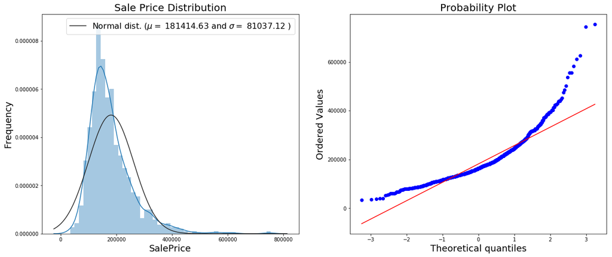

```
The skewness is equal to 1.9647554739521282 %
The Kurtosis is equal to 6.99963735573737 %
```

```python
f = plt.figure(figsize=(20,8))

ax1 = f.add_subplot(1,2,1)
sns.distplot((df_train["SalePrice"]), fit=st.norm, ax=ax1)
# let's plot a histogram with the fitted parameters used by the function
(mu, sigma) = stats.norm.fit(df_train["SalePrice"])
ax1.legend(['Normal dist. ($\mu=$ {:.2f} and $\sigma=$ {:.2f} )'.format(mu, sigma)],
            loc='best', prop={'size': 16})
plt.title('Sale Price Distribution', fontsize=20);
plt.ylabel("Frequency", fontsize=18)
plt.xlabel("SalePrice", fontsize=18)

ax2 = f.add_subplot(1,2,2)
stats.probplot(df_train['SalePrice'], plot=ax2)
plt.title("Probability Plot", fontsize=20);
plt.ylabel("Ordered Values", fontsize=18)
plt.xlabel("Theoretical quantiles", fontsize=18)
plt.show()
print("The skewness is equal to {} % ".format(st.skew(df_train["SalePrice"])))
print("The Kurtosis is equal to {} % ".format(st.kurtosis(df_train["SalePrice"])))
```

What we see on these two plots, and with the [skewness](https://en.wikipedia.org/wiki/Skewness) and [kurtosis](https://en.wikipedia.org/wiki/Kurtosis) descriptors, is that our *SalePrice* distribution is 'far' from normal (mathematically speaking). We can see on the first graph the normal distribution that could best fit our data. If we wish to apply common prediciton models, we will therefore have to make changes to our datasets to make it more normal.

## 2.3 - Looking at the more revelant features

### 2.3.1 - Different type of features

```python
# separating numerical and string columns
numerical_keys=[]
string_keys=[]
for key in df_train.columns:
    if (df_train[key].dtype != 'int64' and df_train[key].dtype!="float64"):
        string_keys.append(key)
    else:
        numerical_keys.append(key)
```

```python
len(numerical_keys)
```

```
37
```

### 2.3.2 - Most revelant features according to the Sale Price

As we know, the goal of this study is to predict the sale price of an house, according to its differents features. Thus it is normal to look at the most correlated features with the Sale Price:

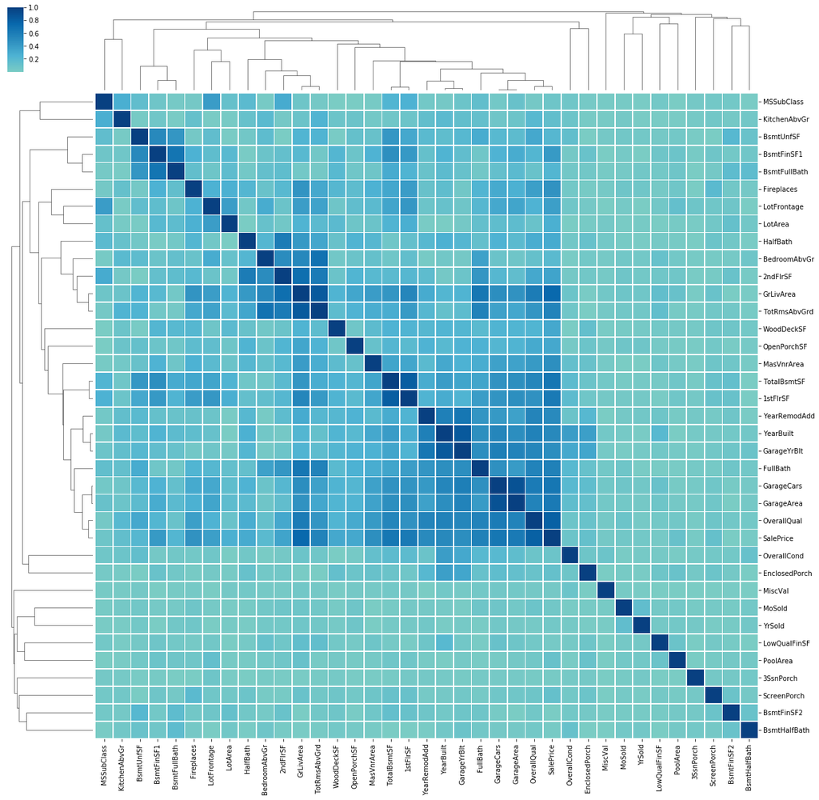

```python
CorrelationMat=df_train.corr().abs()
cm=sns.clustermap(CorrelationMat, center=0, cmap="GnBu",
               linewidths=.75, figsize=(20, 20), metric="correlation")
plt.show()
```

For now, we've still to many features so it's quite hard to understand which features are the most revelant. However, as we want to predict a *Sale Price*, we should look at the features that are the more related to it. Here we can see that obviously the most correlated is *OverallQual* which makes sens. Moreover, we can see, thanks to the cluster that many features are correlated together like Lot frontage and Lot Area

Let's look closer at the the center of the cluser map

```python
display(CorrelationMat.loc["SalePrice"].sort_values(ascending=False))
```

```
SalePrice        1.000000
OverallQual      0.789142
GrLivArea        0.740379
TotalBsmtSF      0.641917
GarageCars       0.640961
GarageArea       0.623329
1stFlrSF         0.618556
FullBath         0.571867
TotRmsAbvGrd     0.559435
YearBuilt        0.523194
YearRemodAdd     0.509916
GarageYrBlt      0.489794
MasVnrArea       0.481406
Fireplaces       0.458528
BsmtFinSF1       0.407568
LotFrontage      0.378387
2ndFlrSF         0.348623
OpenPorchSF      0.315548
WoodDeckSF       0.315379
HalfBath         0.299779
LotArea          0.266811
BsmtFullBath     0.221209
BsmtUnfSF        0.206050
BedroomAbvGr     0.183829
KitchenAbvGr     0.133544
ScreenPorch      0.119891
EnclosedPorch    0.119790
PoolArea         0.103644
OverallCond      0.082580
MSSubClass       0.075817
MoSold           0.047015
YrSold           0.039841
MiscVal          0.036877
LowQualFinSF     0.027071
3SsnPorch        0.020826
BsmtHalfBath     0.017281
BsmtFinSF2       0.002920
Name: SalePrice, dtype: float64
```

Thanks to this graph, we can see that the more related features to the *Sale Prices* are:

- *OverallQual*
- *GrLiveArea*
- *TotalBsmtSF*
- *GarageCars*
- *GarageArea*

### 2.3.3 - Overall Quality

The most important feature according to the Sale Price appears to be the *OverallQual*, wich makes sens because it's the most global feature if you want to describe an entire house. It describe the whole quality of the house and so most of the others features. An other good feature to define the price of an house is its localisations( the neighborhood in our case). However as this feature is not numerical, we dont't have its correlation with the Saleprice for now. So let's just look at *OverallQual*:

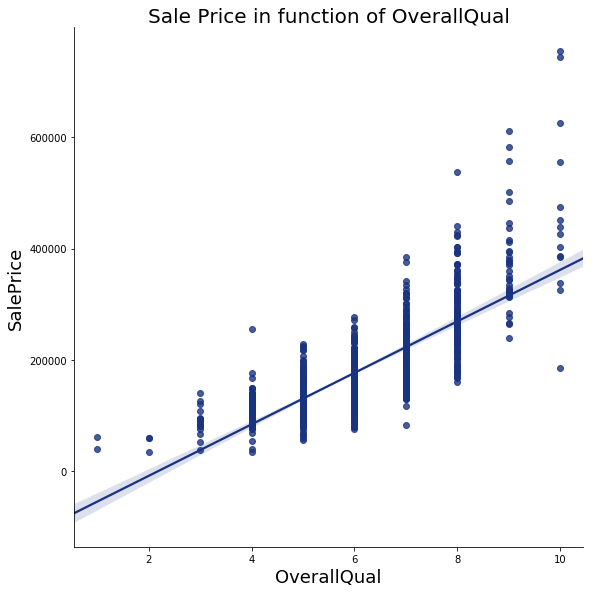

```python
correaltionplot('OverallQual')
```

This graph proves that *Sale Price* and *OverallQual* are highly correlated. Indeed the correlation seems to be a slightly upward curve.

## 2.4 - Ground Living Area

The second most important numerical feature is the *GrLivArea* or Ground living Area.

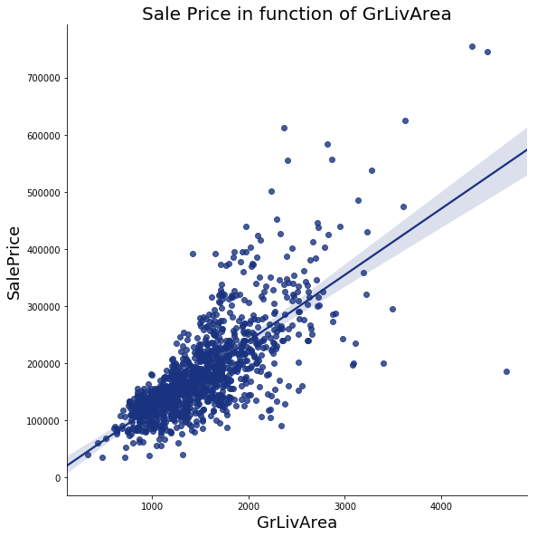

```python
correaltionplot('GrLivArea')
```

In this case, the correlation is slightly less evident but still markworthy. In this graph, we can see some outliers that we will look at later.

### Neighborhoods

As we said the other main feature, when we want to decide the price of an house is its localisation. In our case, the closest thing to its localisations is its Neighborhood, and we know from experience that some neighborhoods are more expensive that some others. So we can take a look at the average price for each neighborhood, just to get a global idea of these.

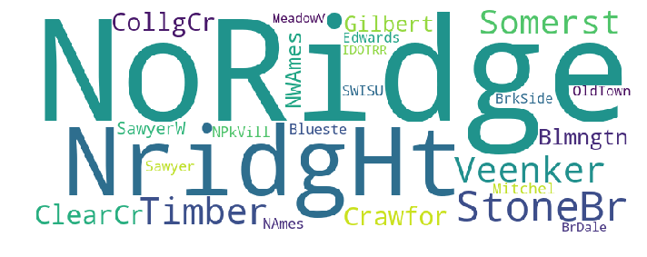

```python
df_train_neighborhoods = pd.read_csv('./challenge_data/train.csv')

avgPrices = pd.DataFrame(df_train_neighborhoods.groupby('Neighborhood').sum()['SalePrice']\
                         /df_train_neighborhoods.groupby('Neighborhood').count()['Id'], columns=['Average price'])
neighborhoods = list(avgPrices['Average price'].keys())
dict_prices={}
for n in neighborhoods:
    dict_prices[n] = avgPrices['Average price'][n]

wordcloud = WordCloud(
    background_color='white',
    min_font_size = 8,
    max_font_size =500,
    height = 300, width = 800,
    ).generate_from_frequencies(dict_prices)

plt.figure( figsize=(10,5) )
plt.imshow(wordcloud)
plt.axis("off")
plt.tight_layout()
plt.show()
```

As we could expect, we can see how some neighborhoods are more expensive than some others (Noridge being the most expensive on average). But this is just a representation and we will look deeper into these neighborhoods later on.

# 3 - Data preparation

Now that we saw what kinda of data values we were dealing with, let us start to prepare them.

## 3.1 - Looking at the missing values

We saw in the first sections that some columns had some `nan` values, so let us go over them:

```python
#we calculate the percentage of missing values in the test set
test_missing_percent=((df_test.isnull().sum()/len(df_test))*100).sort_values(ascending=False)
#same for the training set
train_missing_percent=((df_train.isnull().sum()/len(df_train))*100).sort_values(ascending=False)
#then we can display them
pd.concat([train_missing_percent, test_missing_percent], axis=1, keys=['Train Missing Percent', 'Test Missing Percent'])\
    .sort_values('Test Missing Percent',ascending=False).head(20)
```

|  | Train Missing Percent | Test Missing Percent |
| --- | --- | --- |
| PoolQC | 99.666667 | 98.846154 |
| MiscFeature | 96.083333 | 97.307692 |
| Alley | 93.750000 | 93.846154 |
| Fence | 81.083333 | 79.230769 |
| FireplaceQu | 47.000000 | 48.461538 |
| LotFrontage | 17.500000 | 18.846154 |
| GarageCond | 5.583333 | 5.384615 |
| GarageFinish | 5.583333 | 5.384615 |
| GarageQual | 5.583333 | 5.384615 |
| GarageType | 5.583333 | 5.384615 |
| GarageYrBlt | 5.583333 | 5.384615 |
| BsmtQual | 2.666667 | 1.923077 |
| BsmtFinType2 | 2.750000 | 1.923077 |
| BsmtExposure | 2.750000 | 1.923077 |
| BsmtCond | 2.666667 | 1.923077 |
| BsmtFinType1 | 2.666667 | 1.923077 |
| MasVnrArea | 0.500000 | 0.769231 |
| MasVnrType | 0.500000 | 0.769231 |
| Electrical | 0.000000 | 0.384615 |
| MiscVal | 0.000000 | 0.000000 |

The main question is what should we do with features with an high number of missing values. Indeed, we can see that almost all the values of *PoolQC* are missings which makes this feature quite irrevelant for our problem. However we've decided to just replace them with the most likely appropriate value (mean, median, mode, ..)

## 3.2 - Cleaning up our datasets

We're now going to clean up the data before the preprocessing.

1. Change the missing values regarding the the related variables
2. If a string variable is ordinal we transform it into a numerical one
3. If a numerical variable is chategorical we transform it into a sting one
4. Check if the variable is revelant for the prediction otherway we drop it
5. checking potential outliers
6. Combine some values together

In order to do so, we've decided to work on the value by categories. Indeed there are multiple values that are related together like the pool, the basement, the garage, ... This method is longer than the one before, but it allows us to spend more time on values that are more revelant for the predictions. We present the old cleaning method (much faster but less precise) at the end of this notebook.

As many features use the same system of evaluation, we have decided to use a dictionnary to convert the string into numerical values.

```python
Qualities_Dico={
    'NA' : 0,
    'None' : 0,
    'Po' : 1,
    'Fa' : 2,
    'TA' : 3,
    'Gd' : 4,
    'Ex' : 5
}
```

> We will now go over all of the possible characteristics for the houses and try to understand what can be the best way to modify/use their values.

### 3.2.1 - The Pool

As we said before, there are 2 variables related to the pool:

- *PoolQC* (features with the most missing values)
- *PoolArea* (Ex, Gd, Fa)

```python
df_train['PoolQC'] = df_train['PoolQC'].fillna('None')
df_train['PoolQC'] = df_train['PoolQC'].map(Qualities_Dico)
df_test['PoolQC'] = df_test['PoolQC'].fillna('None')
df_test['PoolQC'] = df_test['PoolQC'].map(Qualities_Dico)
```

```python
df_train[((df_train['PoolArea']>0)&(df_train['PoolQC']==0)) | ((df_train['PoolArea']==0)&(df_train['PoolQC']>0))]
```

|  | MSSubClass | MSZoning | LotFrontage | LotArea | Street | Alley | LotShape | LandContour | Utilities | LotConfig | ... | PoolArea | PoolQC | Fence | MiscFeature | MiscVal | MoSold | YrSold | SaleType | SaleCondition | SalePrice |
| --- | --- | --- | --- | --- | --- | --- | --- | --- | --- | --- | --- | --- | --- | --- | --- | --- | --- | --- | --- | --- | --- |

0 rows × 80 columns

We checked that both of the pool variables are consistent

### 3.2.2 - Misceallous features

*MiscFeature* (Miscellaneous feature not covered in other categories) is the second variable with the most missing values. In that case, we hypothesize that a missing value means no Miscellanous features. Thus we're just going to change them

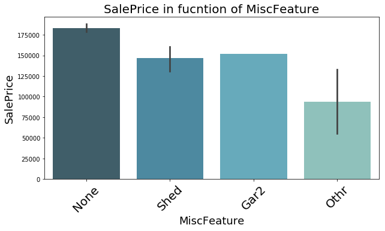

```python
# we replace the missing values by "None"
df_train['MiscFeature'] = df_train['MiscFeature'].fillna('None')

#We plot the SalePrice in function of MiscFeature
f = plt.figure(figsize=(10,5))
sns.barplot(x='MiscFeature',y="SalePrice", data=df_train, palette="GnBu_d")
plt.title('SalePrice in fucntion of MiscFeature', fontsize=20);
plt.xlabel("MiscFeature", fontsize=18)
plt.ylabel("SalePrice", fontsize=18)
plt.xticks(rotation=45, size=20)
plt.show()
```

```python
print("Values in the training set: \n",(df_train['MiscFeature'].value_counts()))

#we fix the test set too
df_test['MiscFeature'] = df_test['MiscFeature'].fillna('None')

print("\nValues in the testing set: \n",(df_test['MiscFeature'].value_counts()))
```

```
Values in the training set:
 None    1153
Shed      44
Othr       2
Gar2       1
Name: MiscFeature, dtype: int64

Values in the testing set:
 None    253
Shed      5
TenC      1
Gar2      1
Name: MiscFeature, dtype: int64
```

It appears that some hous have some specific features in the test set but not in the training set, like the *TenC*. This will have a real impact on our predictions because we can imagine that a house with a tenis court is probably more expensive than a one without. The problem is that we have no way to detemine how much this feature will increase the SalePrice.

### 3.2.3 - Alley

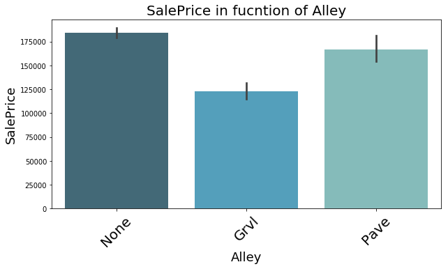

```python
df_train['Alley'] = df_train['Alley'].fillna('None')
df_train['Alley'].value_counts()


#We plot the SalePrice in function of MiscFeature
f = plt.figure(figsize=(10,5))
sns.barplot(x='Alley',y="SalePrice", data=df_train, palette="GnBu_d")
plt.title('SalePrice in fucntion of Alley', fontsize=20);
plt.xlabel("Alley", fontsize=18)
plt.ylabel("SalePrice", fontsize=18)
plt.xticks(rotation=45, size=20)
plt.show()
```

It was predictible that an house with a grave alley is cheaper than one with a pave alley. Now let's check the test set too

```python
print("Values in the training set: \n",(df_train['Alley'].value_counts()))

#we fix the test set too
df_test['Alley'] = df_test['Alley'].fillna('None')

print("\nValues in the testing set: \n",(df_test['Alley'].value_counts()))
```

```
Values in the training set:
 None    1125
Grvl      41
Pave      34
Name: Alley, dtype: int64

Values in the testing set:
 None    244
Grvl      9
Pave      7
Name: Alley, dtype: int64
```

### 3.2.4 - Fence

```python
#first fix the variables
df_train['Fence'] = df_train['Fence'].fillna('None')
print("Values in the training set: \n",(df_train['Fence'].value_counts()))

#we fix the test set too
df_test['Fence'] = df_test['Fence'].fillna('None')

print("\nValues in the testing set: \n",(df_test['Fence'].value_counts()))
```

```
Values in the training set:
 None     973
MnPrv    130
GdPrv     50
GdWo      38
MnWw       9
Name: Fence, dtype: int64

Values in the testing set:
 None     206
MnPrv     27
GdWo      16
GdPrv      9
MnWw       2
Name: Fence, dtype: int64
```

### 3.2.5 - Fireplace variables

There are two variables related the fireplace:

- *FireplaceQu*
- *Fireplaces*

```python
print("Missing Values in the training set: \n",df_train[['FireplaceQu','Fireplaces']].isnull().sum())
print("\nMissing Values in the testing set: \n",df_test[['FireplaceQu','Fireplaces']].isnull().sum())
```

```
Missing Values in the training set:
 FireplaceQu    564
Fireplaces       0
dtype: int64

Missing Values in the testing set:
 FireplaceQu    126
Fireplaces       0
dtype: int64
```

As we can see there are 564 missing values in the *FireplaceQu* variable but none in *Fireplaces*. We've to fix that but the question is "what value to choose for those missings values? ". When there are missings it's probably because there is no fireplace but let's check:

```python
df_train[df_train[['FireplaceQu']].isnull().any(axis=1)]['Fireplaces'].value_counts()
```

```
0    564
Name: Fireplaces, dtype: int64
```

```python
df_test[df_test[['FireplaceQu']].isnull().any(axis=1)]['Fireplaces'].value_counts()
```

```
0    126
Name: Fireplaces, dtype: int64
```

We were right, so we can just change the missings values by *NA* and transform that variable into a numerical one.

```python
#we replace the missing values
df_train['FireplaceQu'] = df_train['FireplaceQu'].fillna("NA")
df_test['FireplaceQu'] = df_test['FireplaceQu'].fillna("NA")
#we transforme the FireplaceQu into a numerical value as this one is ordinal
df_train['FireplaceQu'] = df_train['FireplaceQu'].map(Qualities_Dico)
df_test['FireplaceQu'] = df_test['FireplaceQu'].map(Qualities_Dico)
```

### 3.2.6 - Lot vairables

- *LotFronatage*

```python
print("Missing Values in the training set: \n",df_train[['LotFrontage','LotShape','LotArea', 'LotConfig']].isnull().sum())
print("\nMissing Values in the test set: \n",df_test[['LotFrontage','LotShape','LotArea', 'LotConfig']].isnull().sum())
```

```
Missing Values in the training set:
 LotFrontage    210
LotShape         0
LotArea          0
LotConfig        0
dtype: int64

Missing Values in the test set:
 LotFrontage    49
LotShape        0
LotArea         0
LotConfig       0
dtype: int64
```

Here we've 210 missing values that we need to fix. As *LotFrontage* means "Linear feet of street connected to property", it should be similar in a same neighborhood.

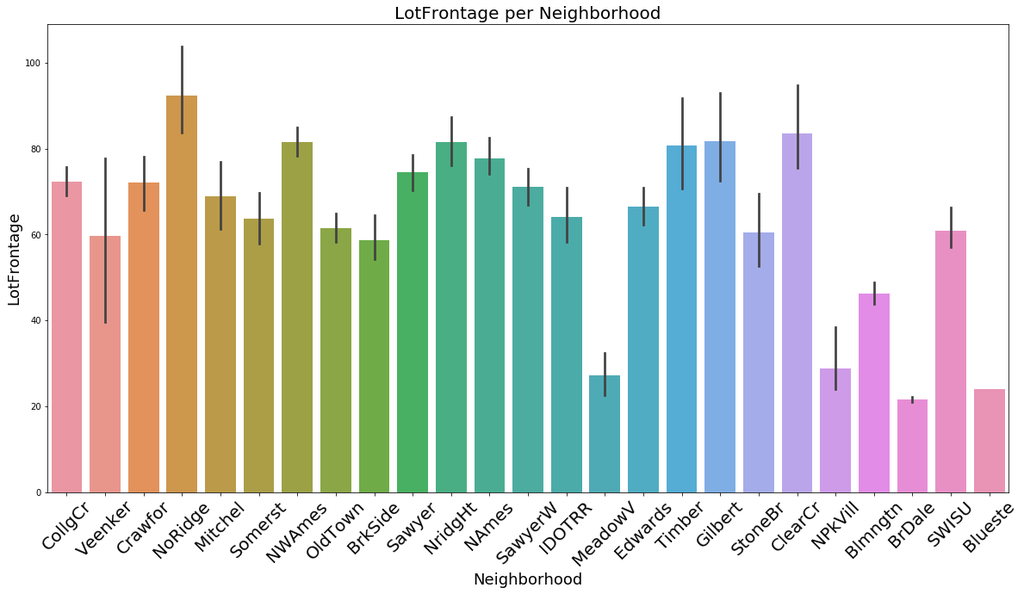

```python
f = plt.figure(figsize=(20,10))
sns.barplot(x='Neighborhood', y="LotFrontage", data=df_train)
plt.title('LotFrontage per Neighborhood', fontsize=20);
plt.ylabel("LotFrontage", fontsize=18)
plt.xlabel("Neighborhood", fontsize=18)
plt.xticks(rotation=45, size=20)
plt.show()
```

As we can see the *LotFrontage* seems effectively to be the same for a Neighborhood. However, as it might have some exceptions we're going to use the median of the LotFrontage of each Neighborhoods to replace the missing values.

```python
df_train["LotFrontage"] = df_train.groupby("Neighborhood")["LotFrontage"]\
            .transform(lambda x: x.fillna(x.median())) #We apply the median of the Neighborhood to the missing values

#Then we're going to fic the test set using the median of the training set
LotFrontage = [df_train.groupby("Neighborhood")['LotFrontage'].median()[row.Neighborhood]\
               if isnan(row.LotFrontage) else row.LotFrontage for index, row in df_test.iterrows() ]

df_test['LotFrontage']=LotFrontage
del LotFrontage
```

- *LotShape*

```python
df_train['LotShape'].value_counts()
```

```
Reg    754
IR1    403
IR2     37
IR3      6
Name: LotShape, dtype: int64
```

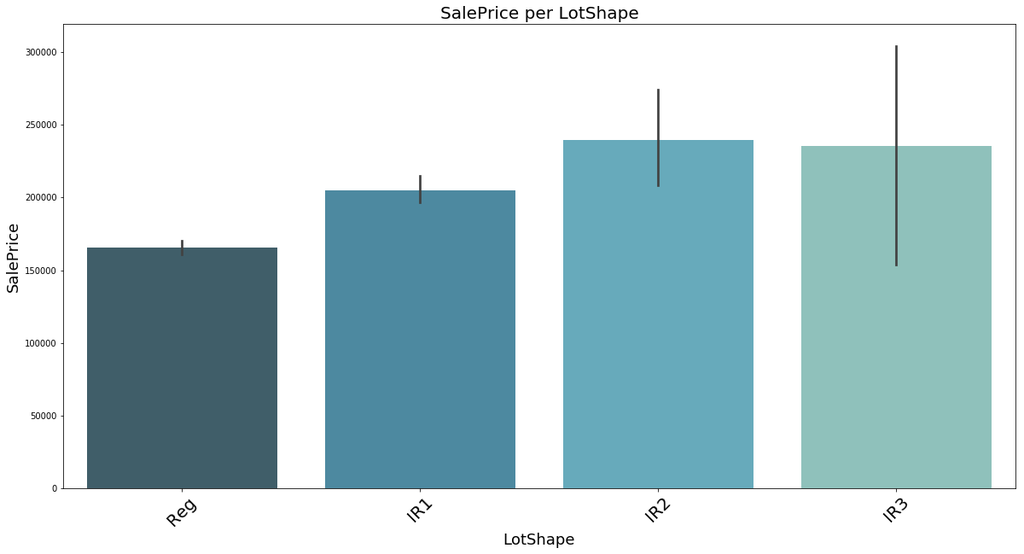

```python
f = plt.figure(figsize=(20,10))
sns.barplot(x='LotShape', y="SalePrice", data=df_train, palette="GnBu_d")
plt.title('SalePrice per LotShape', fontsize=20);
plt.ylabel("SalePrice", fontsize=18)
plt.xlabel("LotShape", fontsize=18)
plt.xticks(rotation=45, size=20)
plt.show()
```

This variable seems to be ordinal. Indeed *Reg* (regular) seems to be the best, not in term of saleprice but in term of accuracy. Thus a regular lot seems to be more predictible than an irregular one. Let's conver this variable into a numerical one:

```python
Dico_tmp={"Reg" : 3,
            'IR1' : 2 ,
            'IR2' : 1 ,
            'IR3' : 0 }
df_train['LotShape'] = df_train['LotShape'].map(Dico_tmp)
df_test['LotShape'] = df_test['LotShape'].map(Dico_tmp)
del Dico_tmp
```

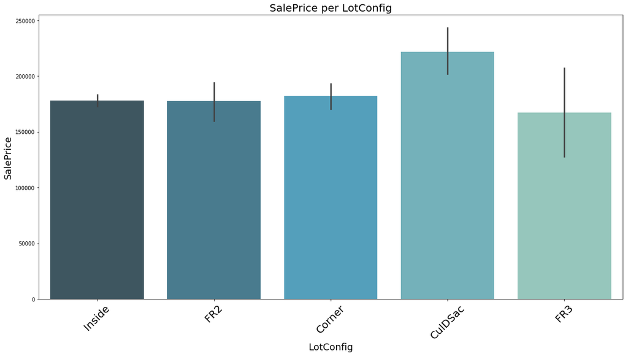

```python
f = plt.figure(figsize=(20,10))
sns.barplot(x='LotConfig', y="SalePrice", data=df_train, palette="GnBu_d")
plt.title('SalePrice per LotConfig', fontsize=20);
plt.ylabel("SalePrice", fontsize=18)
plt.xlabel("LotConfig", fontsize=18)
plt.xticks(rotation=45, size=20)
plt.show()
```

This variable doens't look ordinal for me so we're not going to change it for now.

### 3.2.7 - Kitchen variables

There are two values related to the Kitchen:

- *KitchenQual*
- *KitchenAbvGR* The first one is ordianl so we can change it, but let's check the missing values first:

```python
print("Missing Values in the training set: \n",df_train[['KitchenQual','KitchenAbvGr']].isnull().sum())
print("\nMissing Values in the test set: \n",df_test[['KitchenQual','KitchenAbvGr']].isnull().sum())
```

```
Missing Values in the training set:
 KitchenQual     0
KitchenAbvGr    0
dtype: int64

Missing Values in the test set:
 KitchenQual     0
KitchenAbvGr    0
dtype: int64
```

```python
df_train['KitchenQual'] = df_train['KitchenQual'].map(Qualities_Dico)
df_test['KitchenQual'] = df_test['KitchenQual'].map(Qualities_Dico)
```

### 3.2.8 - MSzoning

```python
print("Missing Values in the training set: \n",df_train['MSZoning'].isnull().sum())
print("\nValues in the training set: \n",df_train['MSZoning'].value_counts())
print("\nMissing Values in the test set: \n",df_test['MSZoning'].isnull().sum())
print("\nValues in the test set: \n",df_test['MSZoning'].value_counts())
```

```
Missing Values in the training set:
 0

Values in the training set:
 RL         946
RM         178
FV          55
RH          12
C (all)      9
Name: MSZoning, dtype: int64

Missing Values in the test set:
 0

Values in the test set:
 RL         205
RM          40
FV          10
RH           4
C (all)      1
Name: MSZoning, dtype: int64
```

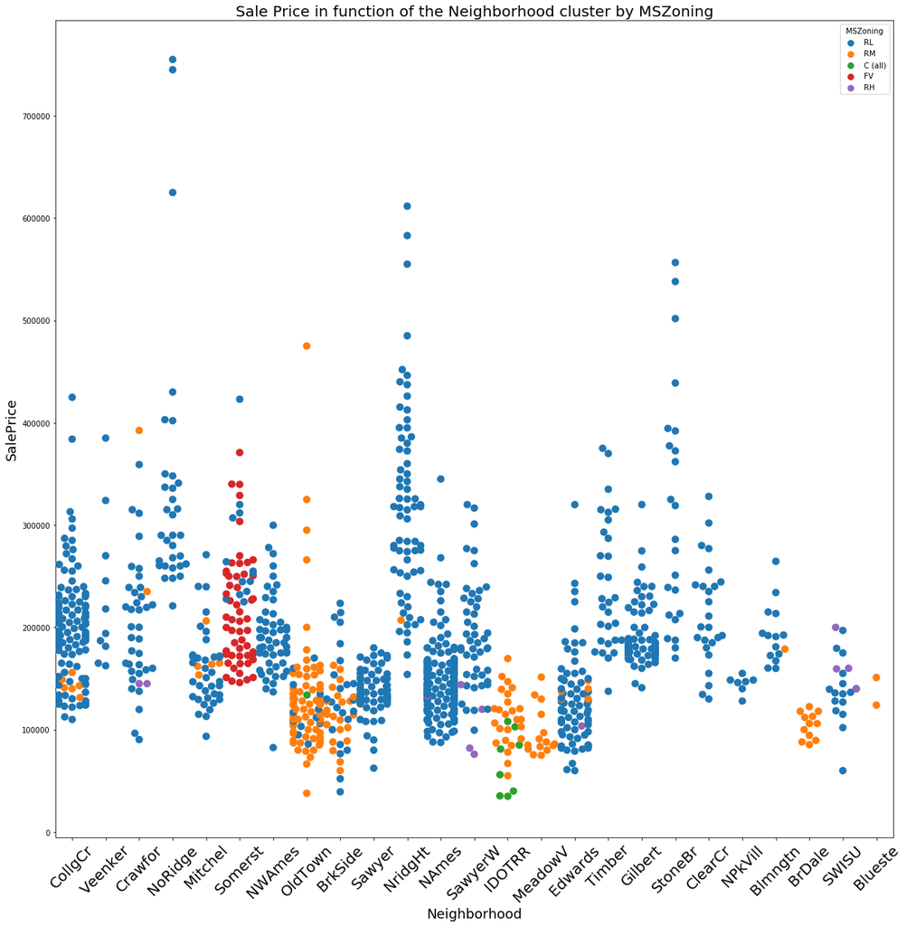

```python
f = plt.figure(figsize=(20,20))
g = sns.swarmplot(data=df_train,
                 y='SalePrice',
                 hue="MSZoning",
                x='Neighborhood',
                 size=10)
plt.title('Sale Price in function of the Neighborhood cluster by MSZoning', fontsize=20);
plt.ylabel("SalePrice", fontsize=18)
plt.xlabel("Neighborhood", fontsize=18)
plt.xticks(rotation=45, size=20)
plt.show()
```

### 3.2.9 - Utilities

```python
print("number of missing values in {}".format(df_train['Utilities'].isnull().sum()))
display(df_train['Utilities'].value_counts())
print("number of missing values in {}".format(df_test['Utilities'].isnull().sum()))
display(df_test['Utilities'].value_counts())
```

```
number of missing values in 0
```

```
AllPub    1199
NoSeWa       1
Name: Utilities, dtype: int64
```

```
number of missing values in 0
```

```
AllPub    260
Name: Utilities, dtype: int64
```

As in the test set all the *Utilities* are the same, this variable sounds useless for the predictions. Thus we can drop it.

```python
df_train.drop('Utilities', axis=1, inplace=True)
df_test.drop('Utilities', axis=1, inplace=True)
```

### 3.2.10 - Functional

```python
print("number of missing values in the training set {}".format(df_train['Functional'].isnull().sum()))
display(df_train['Functional'].value_counts())
print("number of missing values in training set {}".format(df_test['Functional'].isnull().sum()))
display(df_test['Functional'].value_counts())
```

```
number of missing values in the training set 0
```

```
Typ     1117
Min2      28
Min1      25
Maj1      12
Mod       12
Maj2       5
Sev        1
Name: Functional, dtype: int64
```

```
number of missing values in training set 0
```

```
Typ     243
Min2      6
Min1      6
Mod       3
Maj1      2
Name: Functional, dtype: int64
```

As thereis no missing values we can transform the variable as, once again, it's an ordianal variable

```python
Dico_temp={'Typ' : 7,
           'Min1' : 6,
            'Min2' : 5,
            'Mod' : 4,
            'Maj1' : 3,
            'Maj2' : 2,
            'Sev' : 1,
            'Sal' : 0}

df_train['Functional'] = df_train['Functional'].map(Dico_temp)
df_test['Functional'] = df_test['Functional'].map(Dico_temp)

del Dico_temp
```

### 3.2.11 - Exterior variables

```python
print("number of missing values inthe training set \n{}".format(df_train[['ExterCond','ExterQual','Exterior1st','Exterior2nd']].isnull().sum()))
print("\nnumber of missing values in the test set \n{}".format(df_test[['ExterCond','ExterQual','Exterior1st','Exterior2nd']].isnull().sum()))
```

```
number of missing values inthe training set
ExterCond      0
ExterQual      0
Exterior1st    0
Exterior2nd    0
dtype: int64

number of missing values in the test set
ExterCond      0
ExterQual      0
Exterior1st    0
Exterior2nd    0
dtype: int64
```

```python
df_train['ExterCond'] = df_train['ExterCond'].map(Qualities_Dico)
df_train['ExterQual'] = df_train['ExterQual'].map(Qualities_Dico)
display(df_train['ExterCond'].value_counts())
display(df_train['ExterQual'].value_counts())
```

```
3    1050
4     120
2      26
5       3
1       1
Name: ExterCond, dtype: int64
```

```
3    747
4    399
5     43
2     11
Name: ExterQual, dtype: int64
```

### 3.2.12 - Electrical

```python
print("number of missing values in the training set \n{}".format(df_train['Electrical'].isnull().sum()))
print("\nnumber of missing values in the test set \n{}".format(df_test['Electrical'].isnull().sum()))
```

```
number of missing values in the training set
0

number of missing values in the test set
1
```

There is one missing value in the test set. Let's replace it by the mode:

```python
df_test['Electrical'] = df_test['Electrical'].fillna(df_train['Electrical'].mode()[0])
```

```python
display(df_train['Electrical'].value_counts())
display(df_test['Electrical'].value_counts())
```

```
SBrkr    1095
FuseA      80
FuseF      21
FuseP       3
Mix         1
Name: Electrical, dtype: int64
```

```
SBrkr    240
FuseA     14
FuseF      6
Name: Electrical, dtype: int64
```

### 3.2.13 - SaleType

```python
print("number of missing values in the training set \n{}".format(df_train['SaleType'].isnull().sum()))
print("\nnumber of missing values in the test set \n{}".format(df_test['SaleType'].isnull().sum()))
```

```
number of missing values in the training set
0

number of missing values in the test set
0
```

```python
display(df_train['SaleType'].value_counts())
display(df_test['SaleType'].value_counts())
```

```
WD       1036
New       101
COD        37
ConLD       9
ConLw       5
ConLI       5
CWD         3
Con         2
Oth         2
Name: SaleType, dtype: int64
```

```
WD     231
New     21
COD      6
Oth      1
CWD      1
Name: SaleType, dtype: int64
```

### 3.2.14 - SaleCondition

```python
print("number of missing values in the training set \n{}".format(df_train['SaleCondition'].isnull().sum()))
print("\nnumber of missing values in the test set \n{}".format(df_test['SaleCondition'].isnull().sum()))
```

```
number of missing values in the training set
0

number of missing values in the test set
0
```

```python
display(df_train['SaleCondition'].value_counts())
display(df_test['SaleCondition'].value_counts())
```

```
Normal     979
Partial    104
Abnorml     85
Family      17
Alloca      11
AdjLand      4
Name: SaleCondition, dtype: int64
```

```
Normal     219
Partial     21
Abnorml     16
Family       3
Alloca       1
Name: SaleCondition, dtype: int64
```

### 3.2.15 - Neighborhood and pysical location:

There are 3 features that referes to the physical location: *Neighborhood* , *Condition1* and *Condition2*.

```python
print("number of missing values in the training set \n{}".format(df_train[['Neighborhood','Condition1', 'Condition2']].isnull().sum()))
print("\nnumber of missing values in the test set \n{}".format(df_test[['Neighborhood','Condition1', 'Condition2']].isnull().sum()))
```

```
number of missing values in the training set
Neighborhood    0
Condition1      0
Condition2      0
dtype: int64

number of missing values in the test set
Neighborhood    0
Condition1      0
Condition2      0
dtype: int64
```

```python
display(df_train['Neighborhood'].value_counts())
display(df_test['Neighborhood'].value_counts())
```

```
NAmes      179
CollgCr    120
OldTown     95
Edwards     81
Somerst     68
NridgHt     68
Gilbert     67
Sawyer      66
NWAmes      55
SawyerW     51
BrkSide     45
Mitchel     41
Crawfor     40
IDOTRR      33
NoRidge     32
Timber      30
ClearCr     25
StoneBr     23
SWISU       20
MeadowV     15
Blmngtn     15
BrDale      12
Veenker     10
NPkVill      7
Blueste      2
Name: Neighborhood, dtype: int64
```

```
NAmes      46
CollgCr    30
Edwards    19
OldTown    18
Somerst    18
NWAmes     18
BrkSide    13
Gilbert    12
Crawfor    11
NridgHt     9
NoRidge     9
Sawyer      8
SawyerW     8
Mitchel     8
Timber      8
SWISU       5
IDOTRR      4
BrDale      4
ClearCr     3
StoneBr     2
Blmngtn     2
MeadowV     2
NPkVill     2
Veenker     1
Name: Neighborhood, dtype: int64
```

```python
display(df_train['Condition1'].value_counts())
display(df_test['Condition1'].value_counts())
```

```
Norm      1035
Feedr       65
Artery      41
RRAn        21
PosN        17
RRAe         8
PosA         7
RRNn         4
RRNe         2
Name: Condition1, dtype: int64
```

```
Norm      225
Feedr      16
Artery      7
RRAn        5
RRAe        3
PosN        2
PosA        1
RRNn        1
Name: Condition1, dtype: int64
```

```python
display(df_train['Condition2'].value_counts())
display(df_test['Condition2'].value_counts())
```

```
Norm      1186
Feedr        6
Artery       2
RRNn         2
PosN         2
PosA         1
RRAn         1
Name: Condition2, dtype: int64
```

```
Norm    259
RRAe      1
Name: Condition2, dtype: int64
```

We've just seen that none of those features seems to be ordonate for now. Let's look closer at the Neighborhoods.

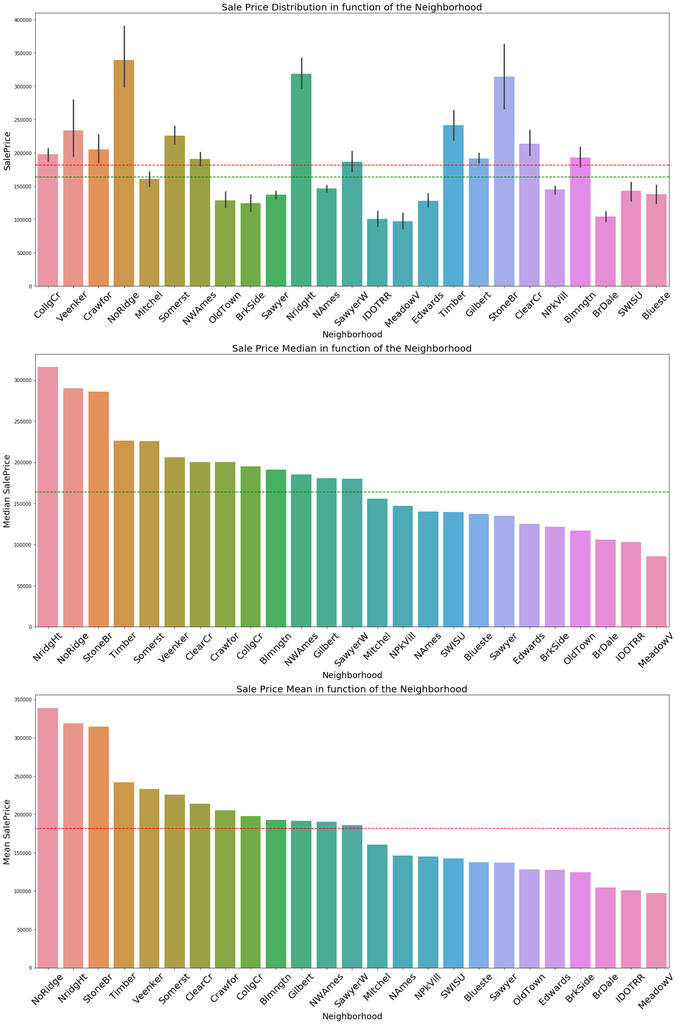

```python
f = plt.figure(figsize=(20,30))
ax1 = f.add_subplot(3, 1, 1)
sns.barplot(x="Neighborhood", y="SalePrice", data=df_train, ax=ax1)
plt.title('Sale Price Distribution in function of the Neighborhood', fontsize=20);
plt.ylabel("SalePrice", fontsize=18)
plt.xlabel("Neighborhood", fontsize=18)
plt.axhline(df_train['SalePrice'].mean(), color='r', linestyle='--')
plt.axhline(df_train['SalePrice'].median(), color='g', linestyle='--')
plt.xticks(rotation=45, size=20)


ax2 = f.add_subplot(3, 1, 2)
df_Neigh=df_train.groupby('Neighborhood')['SalePrice'].median().sort_values(ascending=False)
Neigh=[df_Neigh[i] for i in range(len(df_Neigh))]
sns.barplot(x=df_Neigh.index, y=Neigh, ax=ax2)
plt.title('Sale Price Median in function of the Neighborhood', fontsize=20);
plt.ylabel("Median SalePrice", fontsize=18)
plt.xlabel("Neighborhood", fontsize=18)
plt.axhline(df_train['SalePrice'].median(), color='g', linestyle='--')
plt.xticks(rotation=45, size=20)

ax3 = f.add_subplot(3, 1, 3)
df_Neigh=df_train.groupby('Neighborhood')['SalePrice'].mean().sort_values(ascending=False)
Neigh2=[df_Neigh[i] for i in range(len(df_Neigh))]
sns.barplot(x=df_Neigh.index, y=Neigh2, ax=ax3)
plt.title('Sale Price Mean in function of the Neighborhood', fontsize=20);
plt.ylabel("Mean SalePrice", fontsize=18)
plt.xlabel("Neighborhood", fontsize=18)
plt.axhline(df_train['SalePrice'].mean(), color='r', linestyle='--')
plt.xticks(rotation=45, size=20)

plt.tight_layout()
plt.show()
```

Thanks to those graphs, we can conclude that some neighborhood like *NoRidge*, *Nridght* or *StoneBr* have higher saleprices on the opposite *BrDale*, *IDOTRR* or *MeadowV* are cheaper. We'll use that to cluster the Neighborhoods in 5 categories:

```python
#We create the clustering Dico
Dico_Neighborhood={}
for Nei in df_Neigh.index[:3]:
    Dico_Neighborhood[Nei]=4
for Nei in df_Neigh.index[3:9]:
    Dico_Neighborhood[Nei]=3
for Nei in df_Neigh.index[9:14]:
    Dico_Neighborhood[Nei]=2
for Nei in df_Neigh.index[14:-3]:
    Dico_Neighborhood[Nei]=1
for Nei in df_Neigh.index[-3:]:
    Dico_Neighborhood[Nei]=0
#replace the values in the training set
df_train['Neighborhood'] = df_train['Neighborhood'].map(Dico_Neighborhood)
display(df_train['Neighborhood'].value_counts())
#And also in the test set
df_test['Neighborhood'] = df_test['Neighborhood'].map(Dico_Neighborhood)
display(df_test['Neighborhood'].value_counts())
del Dico_Neighborhood
```

```
1    495
3    293
2    229
4    123
0     60
Name: Neighborhood, dtype: int64
```

```
1    111
3     71
2     48
4     20
0     10
Name: Neighborhood, dtype: int64
```

This transformation might be too much, so we will look at it later during the optimization process.

### 3.2.16 - The bathroom variables

```python
print("number of missing values in the training set \n{}".format(df_train[["FullBath", "HalfBath","BsmtFullBath", "BsmtHalfBath"]].isnull().sum()))
print("\nnumber of missing values in the test set \n{}".format(df_test[["FullBath", "HalfBath","BsmtFullBath", "BsmtHalfBath"]].isnull().sum()))
```

```
number of missing values in the training set
FullBath        0
HalfBath        0
BsmtFullBath    0
BsmtHalfBath    0
dtype: int64

number of missing values in the test set
FullBath        0
HalfBath        0
BsmtFullBath    0
BsmtHalfBath    0
dtype: int64
```

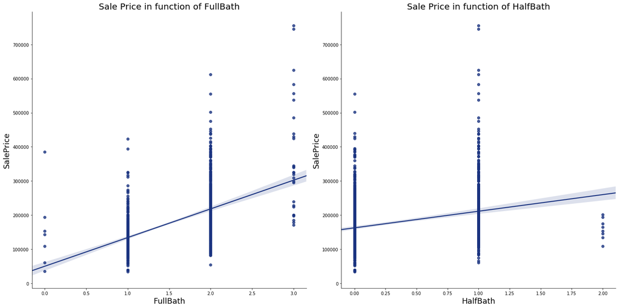

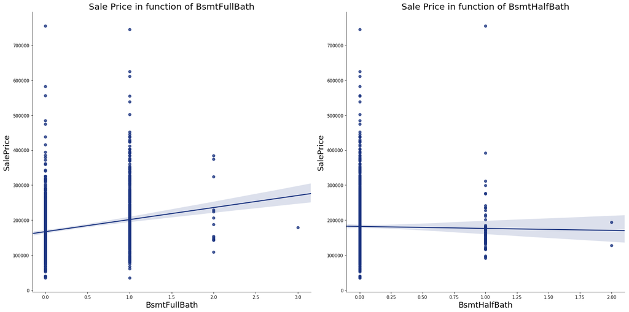

```python
pairgridplots(["FullBath", "HalfBath","BsmtFullBath", "BsmtHalfBath"])
```

```python
TotalBath = [ row.FullBath + 0.5*row.HalfBath +row.BsmtFullBath + 0.5*row.BsmtHalfBath for index, row in df_train.iterrows() ]
df_train['TotalBath']=TotalBath

TotalBath = [ row.FullBath + 0.5*row.HalfBath +row.BsmtFullBath + 0.5*row.BsmtHalfBath for index, row in df_test.iterrows() ]
df_test['TotalBath']=TotalBath

del TotalBath
```

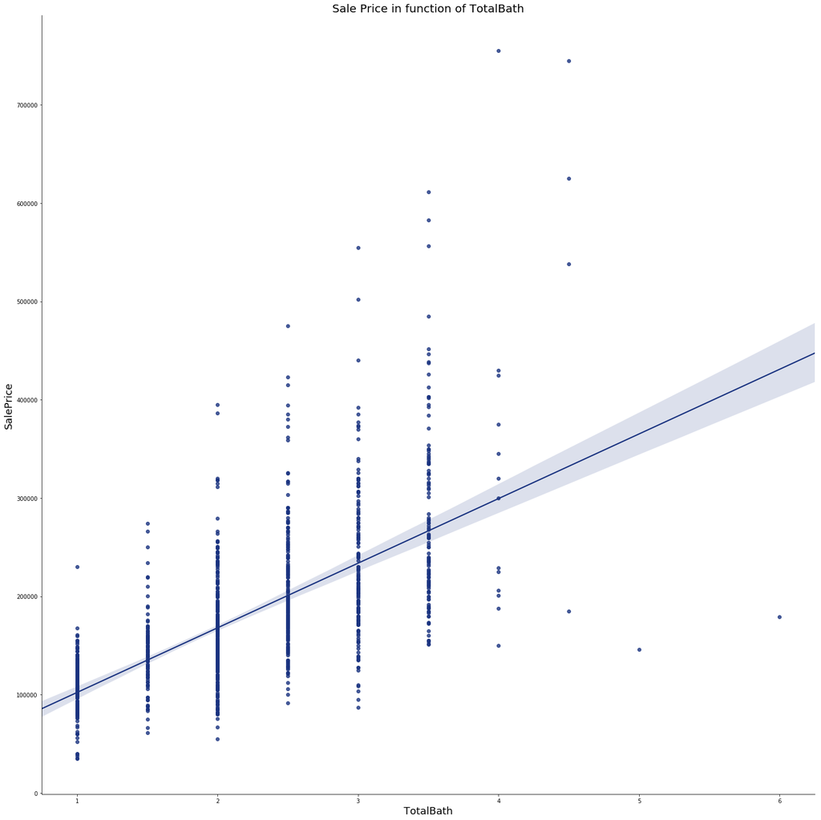

```python
g = sns.PairGrid(df_train,  y_vars=['SalePrice'],x_vars=["TotalBath"], size=20)
g.map(sns.regplot, color=(.1, .2, .5))
plt.title('Sale Price in function of {}'.format("TotalBath"), fontsize=20);
plt.xlabel("TotalBath", fontsize=18)
plt.ylabel("SalePrice", fontsize=18)
plt.show()
```

We can see that this new variable seems to be way more correlatde to the house saleprice. Also, there are still some outliers.

### 3.2.17 - Age

```python
print("number of missing values in the training set \n{}".format(df_train[['YrSold','YearRemodAdd','YearBuilt','MoSold']].isnull().sum()))
print("\nnumber of missing values in the test set \n{}".format(df_test[['YrSold','YearRemodAdd','YearBuilt','MoSold']].isnull().sum()))
```

```
number of missing values in the training set
YrSold          0
YearRemodAdd    0
YearBuilt       0
MoSold          0
dtype: int64

number of missing values in the test set
YrSold          0
YearRemodAdd    0
YearBuilt       0
MoSold          0
dtype: int64
```

We can see that there is no missing values so let's look a bit at two those values: *YrSold* and *MoSold*.

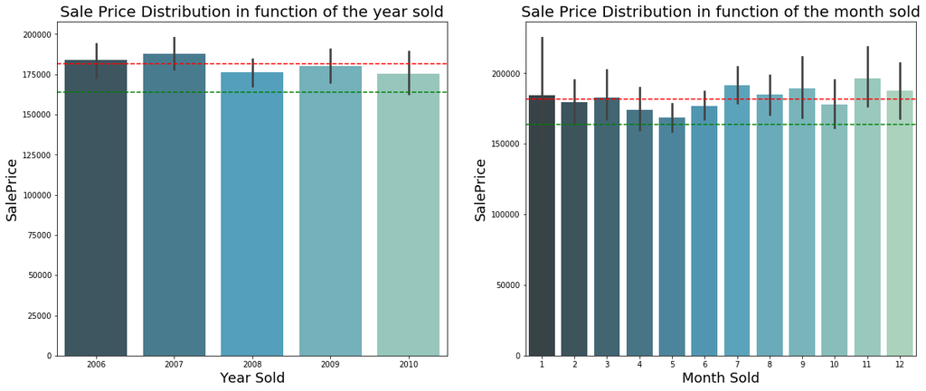

```python
f = plt.figure(figsize=(20,8))
ax1 = f.add_subplot(1,2,1)
sns.barplot(x="YrSold", y="SalePrice", data=df_train, palette="GnBu_d")
plt.title('Sale Price Distribution in function of the year sold', fontsize=20);
plt.ylabel("SalePrice", fontsize=18)
plt.xlabel("Year Sold", fontsize=18)
plt.axhline(df_train['SalePrice'].mean(), color='r', linestyle='--')
plt.axhline(df_train['SalePrice'].median(), color='g', linestyle='--')

ax2 = f.add_subplot(1,2,2)
sns.barplot(x="MoSold", y="SalePrice", data=df_train, palette="GnBu_d")
plt.title('Sale Price Distribution in function of the month sold', fontsize=20);
plt.ylabel("SalePrice", fontsize=18)
plt.xlabel("Month Sold", fontsize=18)
plt.axhline(df_train['SalePrice'].mean(), color='r', linestyle='--')
plt.axhline(df_train['SalePrice'].median(), color='g', linestyle='--')
plt.show()
```

Now let's try to combine some features together.

```python
df_train['Age']= [row.YrSold - row.YearBuilt for index, row in df_train.iterrows() ]
['YrSold','YearRemodAdd','YearBuilt']
df_train['Renovated']= [ 0 if row.YearRemodAdd==row.YearBuilt else 1 for index, row in df_train.iterrows()]

df_test['Age']= [row.YrSold - row.YearBuilt for index, row in df_test.iterrows() ]

df_test['Renovated']= [ 0 if row.YearRemodAdd==row.YearBuilt else 1 for index, row in df_test.iterrows()]
```

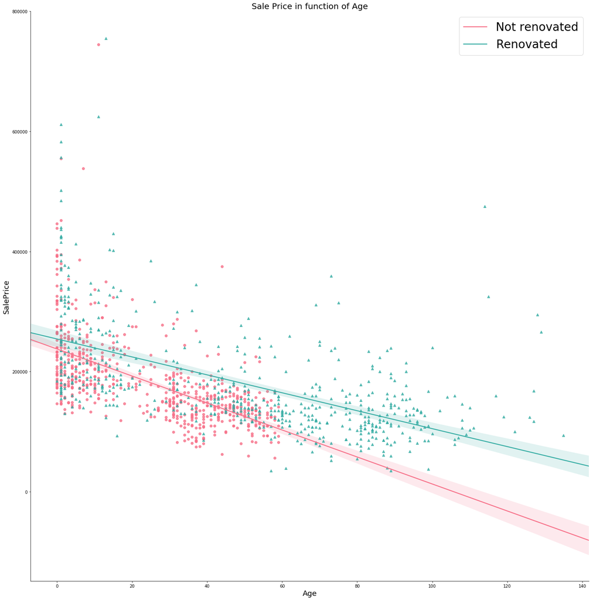

```python
sns.color_palette("husl")
g = sns.lmplot(data=df_train, x='Age', y='SalePrice', hue='Renovated',
                   fit_reg=True, legend=False, legend_out=False,markers= ["o", "^"],palette="husl",
                 size=20)
plt.title('Sale Price in function of {}'.format("Age"), fontsize=20)
plt.xlabel("Age", fontsize=18)
plt.ylabel("SalePrice", fontsize=18)
plt.legend(["Not renovated","Renovated"],fontsize=28)
plt.show()
```

As we can see, there is a high negative correlation between the *Age* and the house *SalePrice*. This makes sens, because an old house is naturally cheaper than a new one. Naturally a renovated house is more expensive

### 3.2.18 - Total square Living Area

```python
print("number of missing values in the training set \n{}".format(df_train[["GrLivArea", "TotalBsmtSF"]].isnull().sum()))
print("\nnumber of missing values in the test set \n{}".format(df_test[["GrLivArea", "TotalBsmtSF"]].isnull().sum()))
```

```
number of missing values in the training set
GrLivArea      0
TotalBsmtSF    0
dtype: int64

number of missing values in the test set
GrLivArea      0
TotalBsmtSF    0
dtype: int64
```

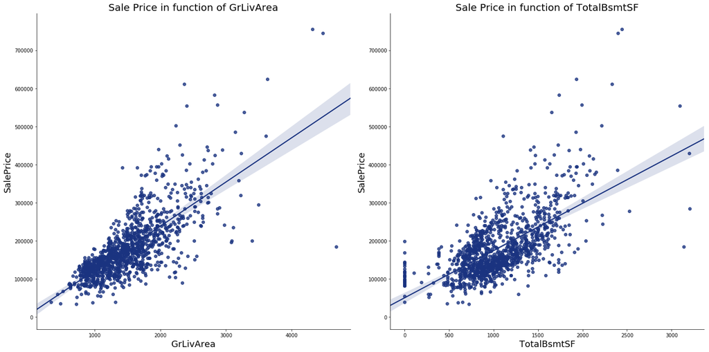

```python
pairgridplots(["GrLivArea", "TotalBsmtSF"])
```

```python
df_train['TotalLivArea']=[ row.GrLivArea + row.TotalBsmtSF for index, row in df_train.iterrows() ]
df_test['TotalLivArea']=[ row.GrLivArea + row.TotalBsmtSF for index, row in df_test.iterrows() ]
```

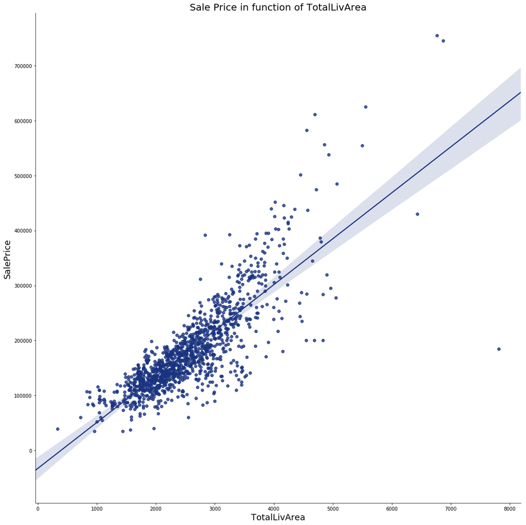

```python
sns.color_palette("husl")
g = sns.PairGrid(df_train,
                 y_vars=['SalePrice'],
                 x_vars=["TotalLivArea"],
                 size=15)
sns.color_palette("husl")
g.map(sns.regplot, color=(.1, .2, .5))
sns.color_palette("husl")
plt.title('Sale Price in function of {}'.format("TotalLivArea"), fontsize=20)
plt.xlabel("TotalLivArea", fontsize=18)
plt.ylabel("SalePrice", fontsize=18)
plt.show()
```

This graph shows a better correlation between the TotalLivArea and the house saleprice. Moreover we can see that there arev some outliers, one in particular. Let's look a bit closer at this one.

```python
display(df_train[((df_train['SalePrice']<200000)&(df_train['TotalLivArea']>7000))])
```

|  | MSSubClass | MSZoning | LotFrontage | LotArea | Street | Alley | LotShape | LandContour | LotConfig | LandSlope | ... | MiscVal | MoSold | YrSold | SaleType | SaleCondition | SalePrice | TotalBath | Age | Renovated | TotalLivArea |
| --- | --- | --- | --- | --- | --- | --- | --- | --- | --- | --- | --- | --- | --- | --- | --- | --- | --- | --- | --- | --- | --- |
| 523 | 60 | RL | 130.0 | 40094 | Pave | None | 2 | Bnk | Inside | Gtl | ... | 0 | 10 | 2007 | New | Partial | 184750 | 4.5 | 0 | 1 | 7814 |

1 rows × 83 columns

As this house is really apart from the others, we will removed it fromthe training set

### 3.2.19 - Garages

Let's look at the variables related to the garages:

- *GarageType*
- *GarageYrBlt*
- *GarageFinish*
- *GarageCars*
- *GarageArea*
- *GarageQual*
- *GarageCond*

```python
Labels=['GarageType',
        'GarageYrBlt',
        'GarageFinish',
        'GarageCars',
        'GarageArea',
        'GarageQual',
        'GarageCond']

print("number of missing values in the training set \n{}".format(df_train[Labels].isnull().sum()))
print("\nnumber of missing values in the test set \n{}".format(df_test[Labels].isnull().sum()))
```

```
number of missing values in the training set
GarageType      67
GarageYrBlt     67
GarageFinish    67
GarageCars       0
GarageArea       0
GarageQual      67
GarageCond      67
dtype: int64

number of missing values in the test set
GarageType      14
GarageYrBlt     14
GarageFinish    14
GarageCars       0
GarageArea       0
GarageQual      14
GarageCond      14
dtype: int64
```

As we can see, 5 of our variables have missing values that we need to fix.

Let's fix *GarageYrBld* by supposing that the Garage was built with the house

```python
df_train['GarageYrBlt']= df_train['GarageYrBlt'].fillna(df_train['YearBuilt'])
df_test['GarageYrBlt']= df_test['GarageYrBlt'].fillna(df_test['YearBuilt'])
```

```python
print("Missing values when there is actually a garage in the training set: {}"
      .format(df_train[df_train[Labels].isnull().any(axis=1)]['GarageCars'].sum()))

print("Missing values when there is actually a garage in the test set: {}"
      .format(df_test[df_test[Labels].isnull().any(axis=1)]['GarageCars'].sum()))
```

```
Missing values when there is actually a garage in the training set: 0
Missing values when there is actually a garage in the test set: 0
```

We can see that the 4 others varaibles with missings values are characters variables and correspond to houses without cars. Thus we should just replace them by *"NA"*

```python
Labels=['GarageType',
        'GarageFinish',
        'GarageQual',
        'GarageCond']

df_train[Labels]= df_train[Labels].fillna("NA")
df_test[Labels]= df_test[Labels].fillna("NA")
```

Now we're going to convers the character variables that seems to be ordinal into numercal variables

```python
#GarageFinish
Dico_Garage={'Fin' : 3 ,
                'RFn' : 2 ,
                'Unf' : 1 ,
                'NA' : 0 }

df_train['GarageFinish'] = df_train['GarageFinish'].map(Dico_Garage)
df_test['GarageFinish'] = df_test['GarageFinish'].map(Dico_Garage)
del Dico_Garage

#Garagequal
df_train['GarageQual'] = df_train['GarageQual'].map(Qualities_Dico)
df_test['GarageQual'] = df_test['GarageQual'].map(Qualities_Dico)

#GarageCond
df_train['GarageCond'] = df_train['GarageCond'].map(Qualities_Dico)
df_test['GarageCond'] = df_test['GarageCond'].map(Qualities_Dico)
```

Now that all the variables related to the garage have been cleaned, we can visualize them.

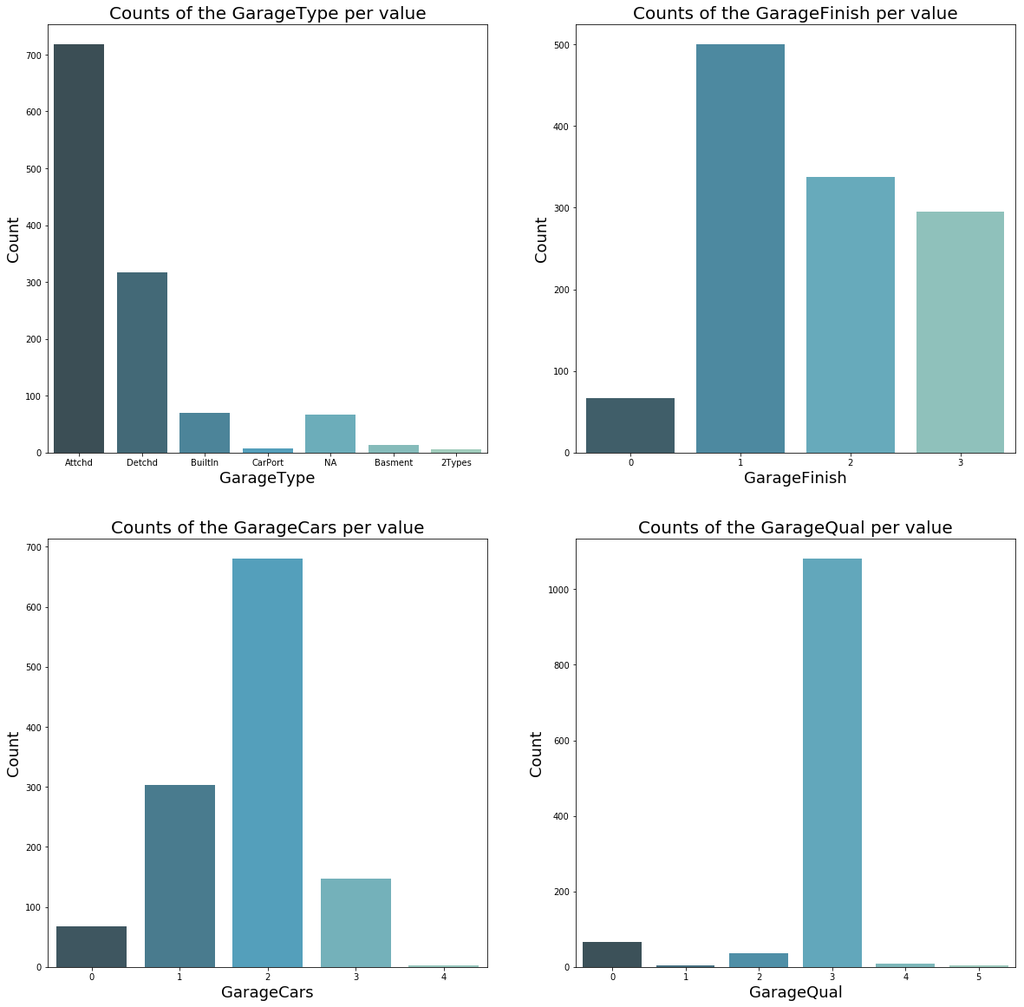

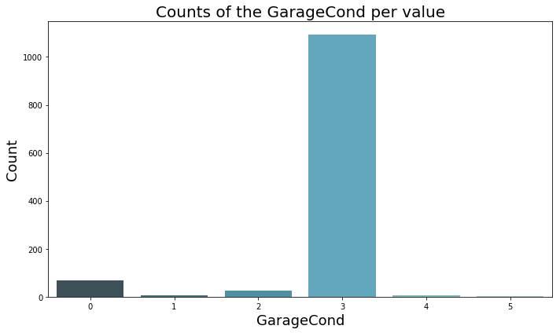

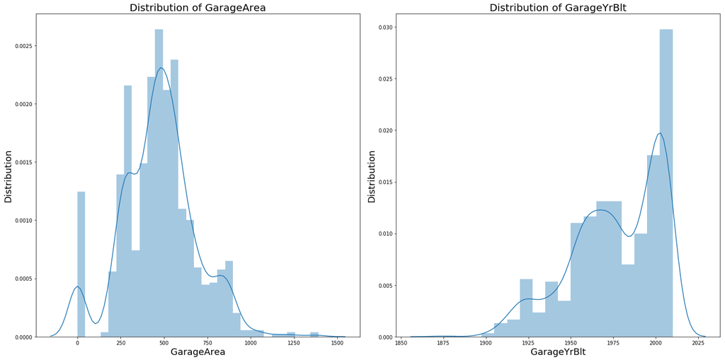

```python
countplots(['GarageType',
 'GarageFinish',
 'GarageCars',
 'GarageQual',
'GarageCond'],df_train)
distplots(['GarageArea','GarageYrBlt'])
```

- *GarageType* we can notice that 2 values are very large making this features not very useful for the predictions. Same for *GarageCond*.
- *on the opposite, features like* GarageArea *,* GarageYrBlt *or* GarageCars* are way more revelant because of their distributions.

```python
Labels=['GarageType',
'GarageYrBlt',
'GarageFinish',
'GarageCars',
'GarageArea',
'GarageQual',
'GarageCond']
```

```python
df_train[Labels].head()
```

|  | GarageType | GarageYrBlt | GarageFinish | GarageCars | GarageArea | GarageQual | GarageCond |
| --- | --- | --- | --- | --- | --- | --- | --- |
| 0 | Attchd | 2003.0 | 2 | 2 | 548 | 3 | 3 |
| 1 | Attchd | 1976.0 | 2 | 2 | 460 | 3 | 3 |
| 2 | Attchd | 2001.0 | 2 | 2 | 608 | 3 | 3 |
| 3 | Detchd | 1998.0 | 1 | 3 | 642 | 3 | 3 |
| 4 | Attchd | 2000.0 | 2 | 3 | 836 | 3 | 3 |

### 3.2.20 - MSSubClass

```python
print("number of missing values in the training set \n{}".format(df_train['MSSubClass'].isnull().sum()))
print("\nnumber of missing values in the test set \n{}".format(df_test['MSSubClass'].isnull().sum()))
```

```
number of missing values in the training set
0

number of missing values in the test set
0
```

```python
df_train['MSSubClass'].describe()
```

```
count    1200.000000
mean       57.075000
std        42.682012
min        20.000000
25%        20.000000
50%        50.000000
75%        70.000000
max       190.000000
Name: MSSubClass, dtype: float64
```

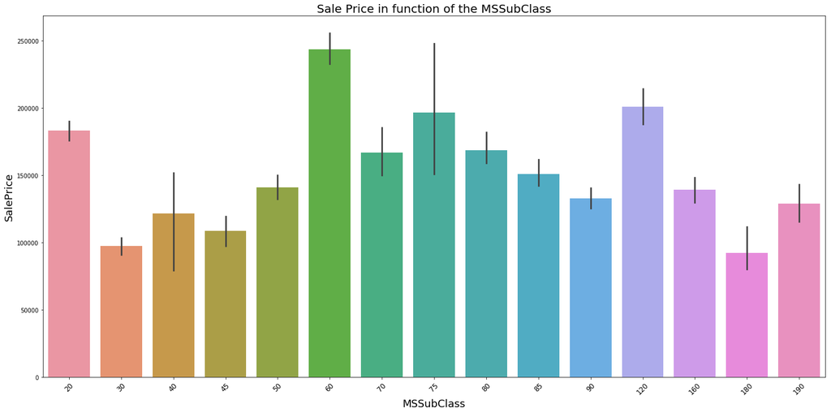

```python
f = plt.figure(figsize=(20,10))
sns.barplot(y='SalePrice',x='MSSubClass',data=df_train)
plt.title('Sale Price in function of the MSSubClass', fontsize=20);
plt.ylabel("SalePrice", fontsize=18)
plt.xlabel("MSSubClass", fontsize=18)
plt.xticks(rotation=45, size=12)

plt.tight_layout()
plt.show()
```

When we look at the description of this variable, we can see that this variable is in fact a categorical variable and not a numerical one. Thus should transform it:

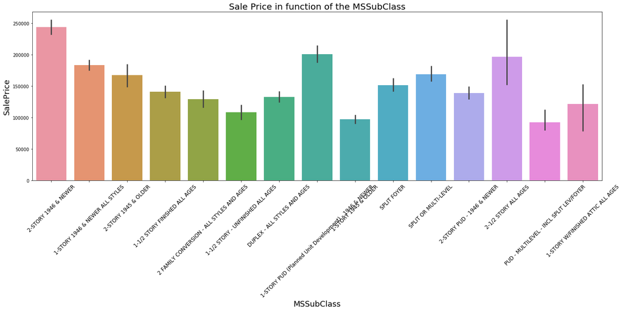

```python
Dico_temp = {20 : '1-STORY 1946 & NEWER ALL STYLES',
                30 : '1-STORY 1945 & OLDER',
                40 : '1-STORY W/FINISHED ATTIC ALL AGES',
                45 : '1-1/2 STORY - UNFINISHED ALL AGES',
                50 : '1-1/2 STORY FINISHED ALL AGES',
                60 : '2-STORY 1946 & NEWER',
                70 : '2-STORY 1945 & OLDER',
                75 : '2-1/2 STORY ALL AGES',
                80 : 'SPLIT OR MULTI-LEVEL',
                85 : 'SPLIT FOYER',
                90 : 'DUPLEX - ALL STYLES AND AGES',
                120 : '1-STORY PUD (Planned Unit Development) - 1946 & NEWER',
                150 : '1-1/2 STORY PUD - ALL AGES',
                160 : '2-STORY PUD - 1946 & NEWER',
                180 : 'PUD - MULTILEVEL - INCL SPLIT LEV/FOYER',
                190 : '2 FAMILY CONVERSION - ALL STYLES AND AGES'}


df_train['MSSubClass'] = df_train['MSSubClass'].map(Dico_temp)
df_test['MSSubClass'] = df_test['MSSubClass'].map(Dico_temp)
del Dico_temp

f = plt.figure(figsize=(20,10))
sns.barplot(y='SalePrice',x='MSSubClass',data=df_train)
plt.title('Sale Price in function of the MSSubClass', fontsize=20);
plt.ylabel("SalePrice", fontsize=18)
plt.xlabel("MSSubClass", fontsize=18)
plt.xticks(rotation=45, size=12)

plt.tight_layout()
plt.show()
```

### 3.2.21 - Basements variables

Let's now talk about the basement variables. There are actually 11 variables related to the basement

- *BsmtCond*
- *BsmtExposure*
- *BsmtFinSF1*
- *BsmtFinSF2*
- *BsmtFinType1*
- *BsmtFinType2*
- *BsmtFullBath*
- *BsmtHalfBath*
- *BsmtQual*
- *BsmtUnfSF*
- *TotalBsmtSF*

```python
Labels = ['BsmtCond',
            'BsmtExposure',
            'BsmtFinSF1',
            'BsmtFinSF2',
            'BsmtFinType1',
            'BsmtFinType2',
            'BsmtFullBath',
            'BsmtHalfBath',
            'BsmtQual',
            'BsmtUnfSF',
            'TotalBsmtSF']
print("number of missing values in the training set \n{}".format(df_train[Labels].isnull().sum()))
print("\nnumber of missing values in the test set \n{}".format(df_test[Labels].isnull().sum()))
```

```
number of missing values in the training set
BsmtCond        32
BsmtExposure    33
BsmtFinSF1       0
BsmtFinSF2       0
BsmtFinType1    32
BsmtFinType2    33
BsmtFullBath     0
BsmtHalfBath     0
BsmtQual        32
BsmtUnfSF        0
TotalBsmtSF      0
dtype: int64

number of missing values in the test set
BsmtCond        5
BsmtExposure    5
BsmtFinSF1      0
BsmtFinSF2      0
BsmtFinType1    5
BsmtFinType2    5
BsmtFullBath    0
BsmtHalfBath    0
BsmtQual        5
BsmtUnfSF       0
TotalBsmtSF     0
dtype: int64
```

We can see that 3 variables have 32 missing values and 2 have 33 missing values. We're going to fix them but first we need to figure out why is there a difference of missing values and which houses are concerned.

```python
#First we check that the variables with the 32 missing values are in the same rows
rows = len(df_train[df_train[['BsmtCond','BsmtFinType1','BsmtQual']]\
                           .isnull().any(axis=1)][['BsmtCond','BsmtFinType1','BsmtQual']].isnull().index)
print("Rows with missing values in those variables: {}".format(rows))

#same for the test set
rows = len(df_test[df_test[['BsmtCond','BsmtFinType1','BsmtQual']]\
                           .isnull().any(axis=1)][['BsmtCond','BsmtFinType1','BsmtQual']].isnull().index)
print("Rows with missing values in those variables: {}".format(rows))
```

```
Rows with missing values in those variables: 32
Rows with missing values in those variables: 5
```

Then we find out why is there a difference of number of missing values.

```python
df_train[df_train[Labels].isnull().any(axis=1)][['BsmtCond']].notnull()\
            .loc[ df_train[df_train[Labels].isnull().any(axis=1)][['BsmtCond']].notnull()['BsmtCond'] == True]
```

|  | BsmtCond |
| --- | --- |
| 332 | True |
| 948 | True |

We find that the houses *332* and *948* are the reason of the difference.

```python
df_train[Labels].iloc[[332,948]]
```

|  | BsmtCond | BsmtExposure | BsmtFinSF1 | BsmtFinSF2 | BsmtFinType1 | BsmtFinType2 | BsmtFullBath | BsmtHalfBath | BsmtQual | BsmtUnfSF | TotalBsmtSF |
| --- | --- | --- | --- | --- | --- | --- | --- | --- | --- | --- | --- |
| 332 | TA | No | 1124 | 479 | GLQ | NaN | 1 | 0 | Gd | 1603 | 3206 |
| 948 | TA | NaN | 0 | 0 | Unf | Unf | 0 | 0 | Gd | 936 | 936 |

```python
df_train[Labels] = df_train[Labels].set_value([332],'BsmtFinType2', df_train['BsmtFinType2'].mode()[0] )
df_train[Labels] = df_train[Labels].set_value([948],'BsmtExposure', df_train['BsmtExposure'].mode()[0] )
```

```python
df_train[Labels].iloc[[332,948]]
```

|  | BsmtCond | BsmtExposure | BsmtFinSF1 | BsmtFinSF2 | BsmtFinType1 | BsmtFinType2 | BsmtFullBath | BsmtHalfBath | BsmtQual | BsmtUnfSF | TotalBsmtSF |
| --- | --- | --- | --- | --- | --- | --- | --- | --- | --- | --- | --- |
| 332 | TA | No | 1124 | 479 | GLQ | Unf | 1 | 0 | Gd | 1603 | 3206 |
| 948 | TA | No | 0 | 0 | Unf | Unf | 0 | 0 | Gd | 936 | 936 |

We can see that we correctly change the two houses.

```python
#BsmtCond & BsmtQual
df_train[['BsmtQual','BsmtCond']]= df_train[['BsmtQual','BsmtCond']].fillna("NA")
df_train['BsmtQual'] = df_train['BsmtQual'].map(Qualities_Dico)
df_train['BsmtCond'] = df_train['BsmtCond'].map(Qualities_Dico)

df_test[['BsmtQual','BsmtCond']]= df_test[['BsmtQual','BsmtCond']].fillna("NA")
df_test['BsmtQual'] = df_test['BsmtQual'].map(Qualities_Dico)
df_test['BsmtCond'] = df_test['BsmtCond'].map(Qualities_Dico)


#BsmtExposure
Expo_dico={"Gd": 4,"Av": 3,"Mn": 2,"No": 1,"NA": 0}
df_train['BsmtExposure']= df_train['BsmtExposure'].fillna("NA")
df_train['BsmtExposure'] = df_train['BsmtExposure'].map(Expo_dico)

df_test['BsmtExposure']= df_test['BsmtExposure'].fillna("NA")
df_test['BsmtExposure'] = df_test['BsmtExposure'].map(Expo_dico)
del Expo_dico

#BsmtFinType
Dico_BsmtFinType={"GLQ" : 6, "ALQ" : 5, "BLQ" : 4, "Rec" : 3, "LwQ" : 2, "Unf" : 1, "NA" : 0}
df_train[['BsmtFinType1','BsmtFinType2']]= df_train[['BsmtFinType1','BsmtFinType2']].fillna("NA")
df_train['BsmtFinType1'] = df_train['BsmtFinType1'].map(Dico_BsmtFinType)
df_train['BsmtFinType2'] = df_train['BsmtFinType2'].map(Dico_BsmtFinType)

df_test[['BsmtFinType1','BsmtFinType2']]= df_test[['BsmtFinType1','BsmtFinType2']].fillna("NA")
df_test['BsmtFinType1'] = df_test['BsmtFinType1'].map(Dico_BsmtFinType)
df_test['BsmtFinType2'] = df_test['BsmtFinType2'].map(Dico_BsmtFinType)

del Dico_BsmtFinType
```

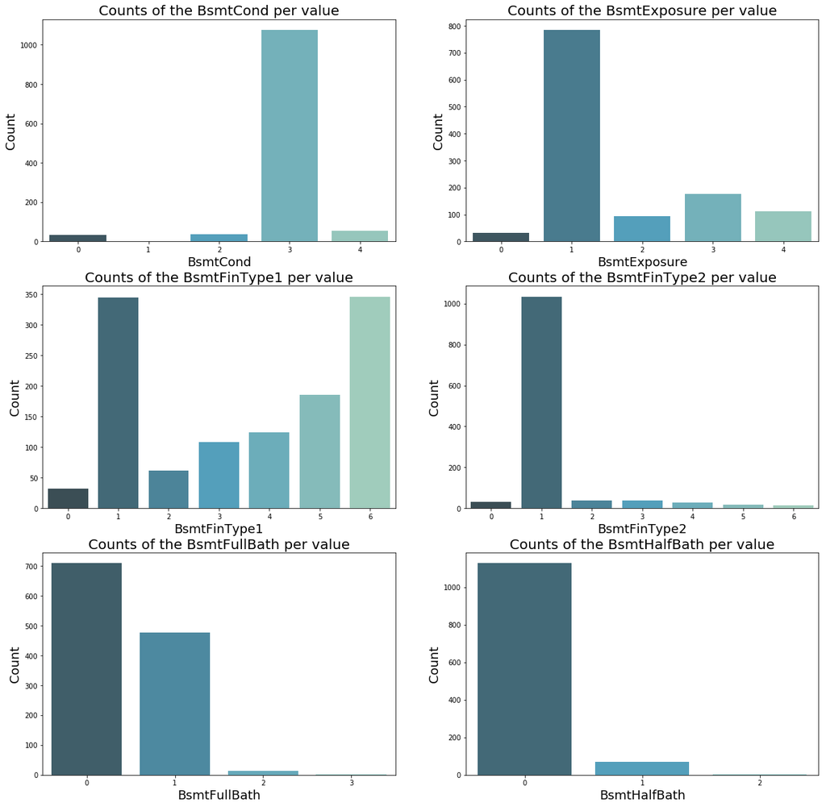

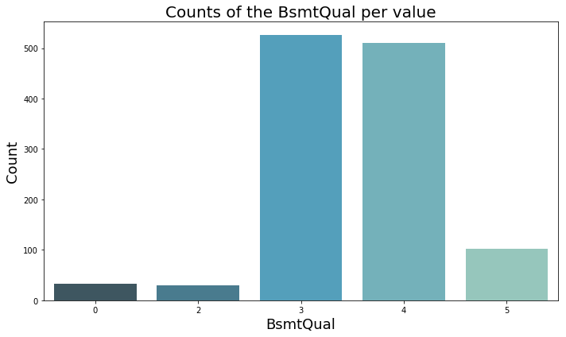

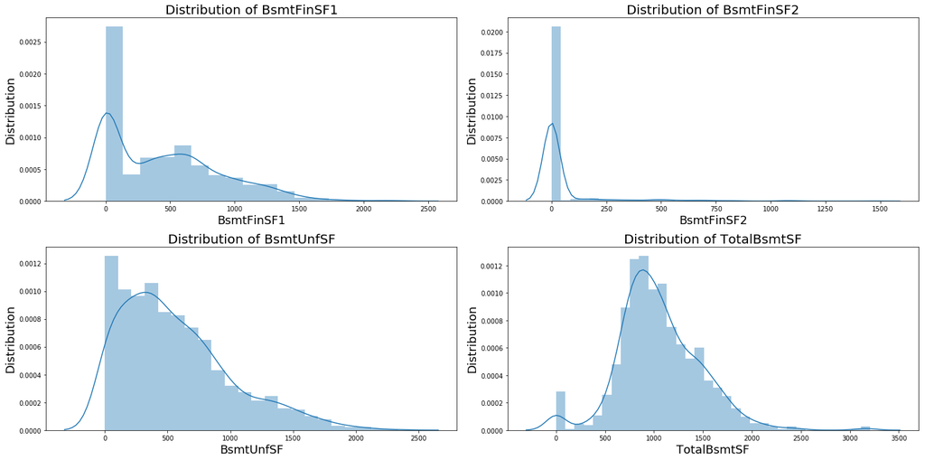

```python
countplots(['BsmtCond',
 'BsmtExposure',
 'BsmtFinType1',
 'BsmtFinType2',
 'BsmtFullBath',
 'BsmtHalfBath',
 'BsmtQual',], df_train)
distplots([ 'BsmtFinSF1',
 'BsmtFinSF2',
 'BsmtUnfSF',
 'TotalBsmtSF'])
```

### 3.2.22 - Porch variables

There is 4 variables related to the porch that we can combine together:

- *OpenPorchSF*
- *EnclosedPorch*
- *3SsnPorch*
- *ScreenPorch*

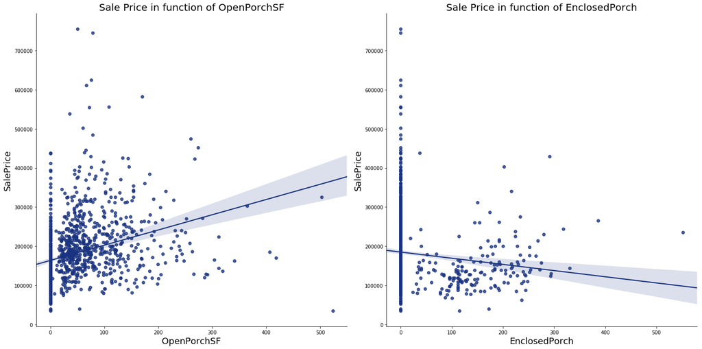

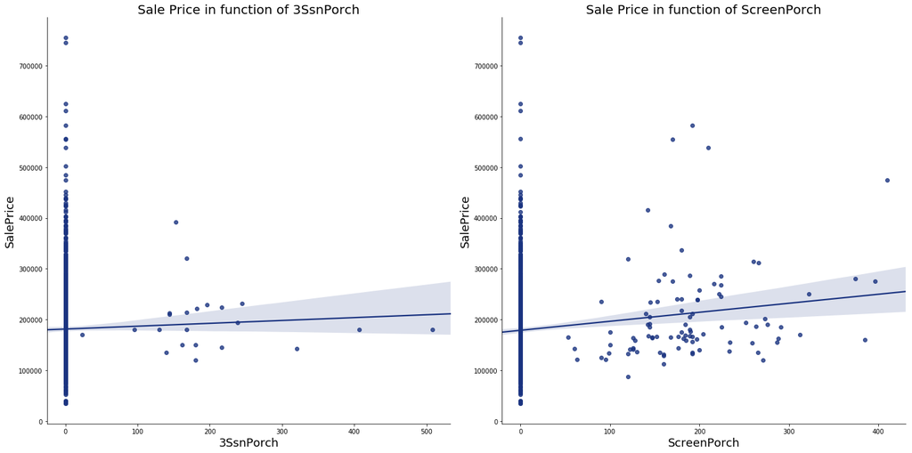

```python
Labels=['OpenPorchSF',
'EnclosedPorch',
'3SsnPorch',
'ScreenPorch']

pairgridplots(Labels)
```

We can see that the regression of the SalePrice in fucntion of those features are terrible. The main reason of that is that most houses don't have a porch. Let's Try to make a new feature with those four to increase the correlation.

```python
print("number of missing values in the training set \n{}".format(df_train[Labels].isnull().sum()))
print("\nnumber of missing values in the test set \n{}".format(df_test[Labels].isnull().sum()))
```

```
number of missing values in the training set
OpenPorchSF      0
EnclosedPorch    0
3SsnPorch        0
ScreenPorch      0
dtype: int64

number of missing values in the test set
OpenPorchSF      0
EnclosedPorch    0
3SsnPorch        0
ScreenPorch      0
dtype: int64
```

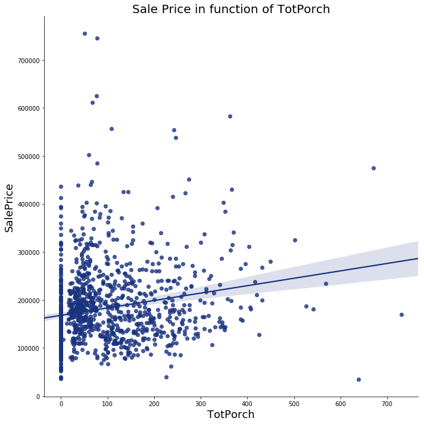

```python
Labels=['OpenPorchSF',
         'EnclosedPorch',
         '3SsnPorch',
         'ScreenPorch',
        'TotPorch']

df_train['TotPorch'] = [row.ScreenPorch + row['3SsnPorch'] + row.EnclosedPorch + row.OpenPorchSF for index, row in df_train.iterrows() ]
df_test['TotPorch'] = [row.ScreenPorch + row['3SsnPorch'] + row.EnclosedPorch + row.OpenPorchSF for index, row in df_test.iterrows() ]

pairgridplots(['TotPorch'])
```

At first sight, the regression looks hardly better. We'll check that later by calculating again the correlation.

### 3.2.23 - Street

```python
print("number of missing values in the training set \n{}".format(df_train['Street'].isnull().sum()))
print("\nnumber of missing values in the test set \n{}".format(df_test['Street'].isnull().sum()))
display(df_train['Street'].value_counts())
display(df_test['Street'].value_counts())
```

```
number of missing values in the training set
0

number of missing values in the test set
0
```

```
Pave    1194
Grvl       6
Name: Street, dtype: int64
```

```
Pave    260
Name: Street, dtype: int64
```

As there only one value in the test set, we can drop that feature like before.

```python
df_train.drop('Street', axis=1, inplace=True)
df_test.drop('Street', axis=1, inplace=True)
```

### 3.2.24 - Heating variables:

```python
print("number of missing values in the training set \n{}".format(df_train[['HeatingQC','CentralAir','Heating']].isnull().sum()))
print("\nnumber of missing values in the test set \n{}".format(df_test[['HeatingQC','CentralAir','Heating']].isnull().sum()))
```

```
number of missing values in the training set
HeatingQC     0
CentralAir    0
Heating       0
dtype: int64

number of missing values in the test set
HeatingQC     0
CentralAir    0
Heating       0
dtype: int64
```

```python
df_train['HeatingQC'] = df_train['HeatingQC'].map(Qualities_Dico)
df_test['HeatingQC'] = df_test['HeatingQC'].map(Qualities_Dico)
df_train['CentralAir'] = df_train['CentralAir'].map({'Y' : 1, 'N' : 0})
df_test['CentralAir'] = df_test['CentralAir'].map({'Y' : 1, 'N' : 0})
```

### 3.2.25 - Masonry variables

- *MasVnrArea*
- *MasVnrType*

```python
print("number of missing values in the training set \n{}".format(df_train[['MasVnrType','MasVnrArea']].isnull().sum()))
print("\nnumber of missing values in the test set \n{}".format(df_test[['MasVnrType','MasVnrArea']].isnull().sum()))
display(df_train['MasVnrType'].value_counts())
display(df_test['MasVnrType'].value_counts())
```

```
number of missing values in the training set
MasVnrType    6
MasVnrArea    6
dtype: int64

number of missing values in the test set
MasVnrType    2
MasVnrArea    2
dtype: int64
```

```
None       711
BrkFace    369
Stone      100
BrkCmn      14
Name: MasVnrType, dtype: int64
```

```
None       153
BrkFace     76
Stone       28
BrkCmn       1
Name: MasVnrType, dtype: int64
```

```python
rows = len(df_train[df_train[['MasVnrType','MasVnrArea']]\
                           .isnull().any(axis=1)][['MasVnrType','MasVnrArea']].isnull().index)
print("Rows with missing values in those variables: {}".format(rows))

rows = len(df_test[df_test[['MasVnrType','MasVnrArea']]\
                           .isnull().any(axis=1)][['MasVnrType','MasVnrArea']].isnull().index)
print("Rows with missing values in those variables: {}".format(rows))
```

```
Rows with missing values in those variables: 6
Rows with missing values in those variables: 2
```

```python
df_train['MasVnrType']=df_train['MasVnrType'].fillna("None")
df_train['MasVnrArea']=df_train['MasVnrArea'].fillna(0)
df_test['MasVnrType']=df_test['MasVnrType'].fillna("None")
df_test['MasVnrArea']=df_test['MasVnrArea'].fillna(0)
```

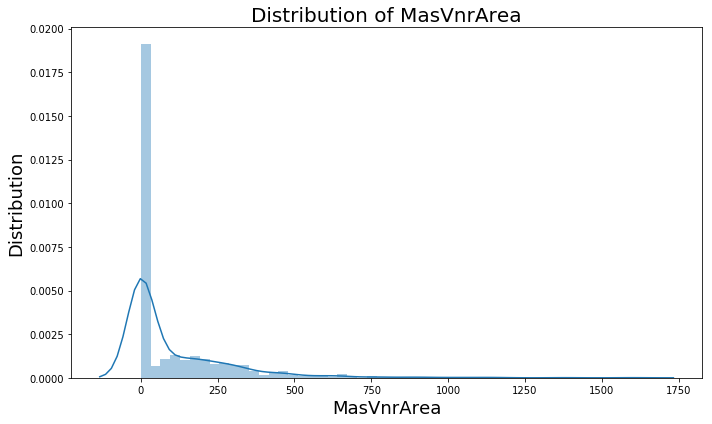

```python
distplots(['MasVnrArea'])
```

# 4 - Data Preprocessing

Now that our data is ready for the models, we still need to do a little preprocessing before feeding it to our models.

Over the previous sections, we added some new columns to better represent original columns. So we can start by dropping these columns out.

## New Correlation

```python
CorrelationMat=df_train.corr().abs()
display(CorrelationMat.loc["SalePrice"].sort_values(ascending=False))
```

```
SalePrice        1.000000
TotalLivArea     0.820309
OverallQual      0.789142
GrLivArea        0.740379
Neighborhood     0.694641
ExterQual        0.679614
KitchenQual      0.656790
TotalBsmtSF      0.641917
GarageCars       0.640961
TotalBath        0.639127
GarageArea       0.623329
1stFlrSF         0.618556
BsmtQual         0.583619
FullBath         0.571867
TotRmsAbvGrd     0.559435
GarageFinish     0.542407
Age              0.524754
YearBuilt        0.523194
FireplaceQu      0.516023
GarageYrBlt      0.512506
YearRemodAdd     0.509916
MasVnrArea       0.480350
Fireplaces       0.458528
HeatingQC        0.435500
BsmtFinSF1       0.407568
LotFrontage      0.374177
BsmtExposure     0.365117
2ndFlrSF         0.348623
OpenPorchSF      0.315548
WoodDeckSF       0.315379
BsmtFinType1     0.304964
HalfBath         0.299779
LotArea          0.266811
GarageQual       0.265899
LotShape         0.264568
GarageCond       0.250996
CentralAir       0.247407
BsmtFullBath     0.221209
BsmtUnfSF        0.206050
BsmtCond         0.205340
TotPorch         0.197830
BedroomAbvGr     0.183829
KitchenAbvGr     0.133544
PoolQC           0.129776
ScreenPorch      0.119891
EnclosedPorch    0.119790
Functional       0.108660
PoolArea         0.103644
OverallCond      0.082580
MoSold           0.047015
YrSold           0.039841
MiscVal          0.036877
LowQualFinSF     0.027071
3SsnPorch        0.020826
ExterCond        0.020513
BsmtHalfBath     0.017281
BsmtFinType2     0.005016
Renovated        0.003836
BsmtFinSF2       0.002920
Name: SalePrice, dtype: float64
```

```python
df_train.drop(["FullBath", "HalfBath","BsmtFullBath", "BsmtHalfBath",'YrSold',
               'YearRemodAdd','YearBuilt',"GrLivArea", "TotalBsmtSF",
              'OpenPorchSF','EnclosedPorch','3SsnPorch','ScreenPorch'], axis=1, inplace=True)
df_test.drop(["FullBath", "HalfBath","BsmtFullBath", "BsmtHalfBath",'YrSold',
               'YearRemodAdd','YearBuilt',"GrLivArea", "TotalBsmtSF",
              'OpenPorchSF','EnclosedPorch','3SsnPorch','ScreenPorch'], axis=1, inplace=True)

#Dropping some outliers
df_train.drop(index=523, inplace=True)
```

There are still some variables that we have keep as string variables. Now we need to prepare them to be used during the modeling:

## Skewness

What we can observe next is that the data distributions are too asymetric, so we wish to make them more 'normal', in order to be able to use more models (which assume the datasets are close to normal distributions). To do so, we are going to apply the **Box-Cox transformation** to our columns.

**Note:** We do not apply it to two columns (`Age`, `GarageYrBlt`), because the resulting values are too high for some of the computations we do later on. More specifically, they are too high to be put into `float32` variables, which we need with some of the `sktlean` functions.

```python
t0=time()
norm_train = df_train.copy()
norm_test = df_test.copy()
for col in df_train.columns:
    if col not in ['Age',  'GarageYrBlt'] and norm_train[col].dtype!='object':
        norm_train[col] = norm_train[col].map(lambda y: y+2)
        lmbda=stats.boxcox_normmax(norm_train[col], (-5, 5))
        if col=='SalePrice': salePriceLambda = lmbda
        norm_train[col] = stats.boxcox(norm_train[col], lmbda)
        try:
            norm_test[col] = norm_test[col].map(lambda y: y+2)
            lmbda_test=stats.boxcox_normmax(norm_test[col], (-5, 5))
            norm_test[col] = stats.boxcox(norm_test[col], lmbda)
        except:
            pass # SalePrice not in norm_test
print('[TIME] Applying Box-Cox to training and test data took: %.3fs' % (time() - t0))
```

```
[TIME] Applying Box-Cox to training and test data took: 0.647s
```

**Note:** When applying the Box-Cox transformation to the *SalePrice* column, we save the `lambda` value (used in the Box-Cox formula) into a variable (`salePriceLambda`) so that we can use it again at the end of the notebook when converting back our `SalePrices` to dollars.

#### Example of the Box-Cox Transformation

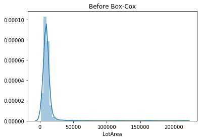

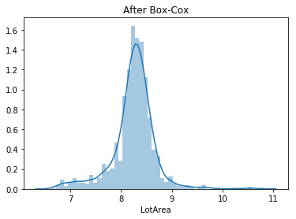

```python
col = 'LotArea' #df_train.columns[rd.randint(0, len(df_train.columns)-1)]
sns.distplot(df_train[col])
plt.title("Before Box-Cox")
plt.show()
plt.figure()
sns.distplot(norm_train[col])
plt.title("After Box-Cox")
plt.show()
```

```python
cols = [col for col in norm_train.columns if norm_train[col].dtype=='object']

# process columns, apply LabelEncoder to categorical features
for c in cols:
    lbl = LabelEncoder()
    lbl.fit(list(norm_train[c].values))
    norm_train[c] = lbl.transform(list(norm_train[c].values))

# shape
print('Shape of the training data: {}'.format(norm_train.shape))
```

```
Shape of the training data: (1199, 70)
```

```python
cols = [col for col in norm_test.columns if norm_test[col].dtype=='object']

# process columns, apply LabelEncoder to categorical features
for c in cols:
    lbl = LabelEncoder()
    lbl.fit(list(norm_test[c].values))
    norm_test[c] = lbl.transform(list(norm_test[c].values))

# shape
print('Shape of the test data: {}'.format(norm_test.shape))
```

```
Shape of the test data: (260, 69)
```

```python
norm_train = pd.get_dummies(norm_train)
norm_test = pd.get_dummies(norm_test)
```

```python
print('Shape of the training data: {}'.format(norm_train.shape))
print('Shape of the test data: {}'.format(norm_test.shape))
```

```
Shape of the training data: (1199, 70)
Shape of the test data: (260, 69)
```

# 5 - Modeling

We decided for the *modeling* section to try different prediction models, and to see how each one of them would compare with the others. All of them are from the implementations in `sklearn`, but it is possible to find other models from other libraries as well. More particularly, we would have liked to try to use a more complex network with PyTorch or TensorFlow.

### Outline:

- Cross Validation
- Models:
  1. Random Forest
  2. Support Vector Machines
  3. K-Nearest Neighbors
  4. Multi-Layer Perceptron
  5. Lasso
  6. AdaBoost
  7. Bagging Regressor
  8. Extra-trees Regressor
  9. Gradient Boosting Regressor
  10. Ridge

### Cross-validation

To test our different models, we are going to use the cross-validation method: we split our training dataset into two subsets:

1. a training subset, used to train our models
2. a test/validation subset, to test (and check) our predictions

Once we have "good enough" results using cross-validation, we will predict the prices for the initial test dataset.

So we first need to divide our training dataset into two sub-sets. To do so, we are going to use the [`train_test_split()`](http://scikit-learn.org/stable/modules/generated/sklearn.model_selection.train_test_split.html) function from `sklearn`:

```python
# training set: 90%; test set: 10%
train_data, test_data = train_test_split(norm_train, test_size=.1)
print("Length of training set: {}\nLength of test set: {}".format(len(train_data), len(test_data)))
```

```
Length of training set: 1079
Length of test set: 120
```

Then for both test and training sets, we are going to take out the `SalePrice` column which represents the results we are training on.

```python
train_targets = train_data['SalePrice']
train_data.drop('SalePrice', axis=1, inplace=True)
test_targets = test_data['SalePrice']
test_data.drop('SalePrice', axis=1, inplace=True)
```

We are now going to try different models to try a find good regressors with the best possible `SalePrice` predictions. We will store all of the predictions in one single dictionary `predictions` to ease up the evalutation part later on.

```python
predictions = {}
```

For most of the models we'll study, we are going to use the same code structure:

1. Initiate the regressor
2. Fit the regressor while finding the best possible parameters:
   - To find the best possible values for a given regressor's parameters, we are going to use [the `GridSearchCV` function](http://scikit-learn.org/stable/modules/generated/sklearn.model_selection.GridSearchCV.html) from `sklearn`. Given a range of possible values for specific parameters, `GridSearchCV` will find the best combination of these parameters. It returns the regressor object which we can use right away with `fit()` and `predict()`.
3. Predict prices for the test subset

Therefore, we are going to use a function that we will do all three steps, given a regressor and some parameters:

```python
def buildAndPredict(regressor, params, name, datasets, displayParams=True):
    '''
        regressor = sklearn.ensemble regressor object, already initiliazed
        params = parameters to be tested with GridSearchCV to optimize the regressor
        name = name to be given to the regressor and its results
        datasets = training data, training targets, test data for the predictions
        displayParams (True by default) = boolean to indicate whether the script should display
                                            the regressor's optimized parameters
    '''
    # recover training/test data if needed
    train_data = datasets[0]
    train_targets = datasets[1]
    test_data = datasets[2]

    # initiate regressor with GridSearchCV
    rgr = GridSearchCV(regressor, params)

    # find best parameters and train the regressor
    t0=time()
    rgr.fit(train_data, train_targets)
    print("Training %s took %.3fs." % (name, (time() - t0)))

    if displayParams: print("\nRegressor's params:\n", rgr.best_estimator_)

    # predict test prices
    return rgr.predict(test_data)
```

## 5.1 - Random Forest model

Random forests or *random decision forests* are an **ensemble learning method** for *classification*, *regression* and other tasks, that operate by constructing a multitude of decision trees at training time and outputting the class that is the mode of the classes (classification) or mean prediction (regression) of the individual trees. ([Wikipedia](https://en.wikipedia.org/wiki/Random_forest))

```python
from sklearn.ensemble import RandomForestRegressor
from sklearn.model_selection import GridSearchCV
```

### Parameters

The `max_depth` parameter is set to `None` by default, which can lead to a very large tree on some datasets. Fortunately, we do not have a very big dataset so we can assume that our trees will never be "too" large. We can still decide to set the value of that parameter, to reduce memory consumption and the complexity of our regressor.

Moreover, we could fix `random_state` to obtain deterministic behaviors. We do not do so here because we want to see how heterogeneous our results can be.

```python
params = {'max_depth': [15, 20, 25],
          'n_estimators': [115, 120, 125]}

predictions["Random Forest"] = buildAndPredict(
    RandomForestRegressor(),
    params,
    "Random Forest",
    datasets=[train_data, train_targets, test_data]
)
```

```
Training Random Forest took 34.722s.

Regressor's params:
 RandomForestRegressor(bootstrap=True, criterion='mse', max_depth=20,
           max_features='auto', max_leaf_nodes=None,
           min_impurity_decrease=0.0, min_impurity_split=None,
           min_samples_leaf=1, min_samples_split=2,
           min_weight_fraction_leaf=0.0, n_estimators=120, n_jobs=1,
           oob_score=False, random_state=None, verbose=0, warm_start=False)
```

## 5.2 - Support Vector Machines

We are going to use Support Vector Machines to build an efficient classifier. To do so, we decided to use the [Sklearn SVM module](http://scikit-learn.org/stable/modules/svm.html). From that module, we are going to use the [Support Vector Regressor (SVR) module](http://scikit-learn.org/stable/modules/generated/sklearn.svm.SVR.html).

### Support Vector Regressor (SVR)

We chose the Radial Basis Function (RBF) kernel for our SVM. This kernel is implemented in `sklearn.svm` with two parameters: `gamma` and `C`.

As stated in the [documentation page of the RBF kernel](http://scikit-learn.org/stable/auto_examples/svm/plot_rbf_parameters.html) for SVM:

- Intuitively, the `gamma` parameter defines how far the influence of a single training example reaches, with low values meaning ‘far’ and high values meaning ‘close’.
- The `C` parameter trades off misclassification of training examples against simplicity of the decision surface. A low `C` makes the decision surface smooth, while a high `C` aims at classifying all training examples correctly by giving the model freedom to select more samples as support vectors.

### Scaler

As advised in the documentation, we used `StandardScaler` to scale our dataset to smaller intervals. It standardizes the dataset vectors to have mean 0 and variance 1, because of the SVR's sensitivity to *feature scaling*. Empirically, it gives us much better results (as expected) but also takes longer to train.

```python
from sklearn.svm import SVR
from sklearn import preprocessing
from sklearn.preprocessing import StandardScaler
```

```python
# encoding train_targets from <floats> to <integers>
#lab_enc = preprocessing.LabelEncoder()
#train_targets_svm_enc = train_targets_svm.map(lambda x: int(x*(10**8)))#fit_transform(train_targets_svm.values)

scaler_svr = StandardScaler()
scaler_svr.fit(train_data)
SVR_train = scaler_svr.transform(train_data)
SVR_test = scaler_svr.transform(test_data)

# ranges of possible values for <gamma>, <epsilon>
#C_range = np.logspace(-2, 10, 13)
gamma_range = [0.01, 0.1, 1, 2, 3, 5, 10] #np.logspace(-9, 3, 13)
epsilon_range = [0.001, 0.01, 0.5]
#kernel_vals = ['rbf', 'linear', 'sigmoid', 'poly']
params = {'gamma':gamma_range, 'epsilon':epsilon_range}

# using <GridSearchCV()> to find the best combination of <gamma> and <C>
svc = SVR()
clf = GridSearchCV(svc, params)

# building the SVM regressor with the training dataset
t0 = time()
clf.fit(SVR_train, train_targets)
print("SVR fit took %.3fs" % (time() - t0))

print("\nRegressor's params:\n", clf.best_estimator_)
```

```
SVR fit took 7.800s

Regressor's params:
 SVR(C=1.0, cache_size=200, coef0=0.0, degree=3, epsilon=0.01, gamma=0.01,
  kernel='rbf', max_iter=-1, shrinking=True, tol=0.001, verbose=False)
```

### Predictions

Now that our regressor is trained, let's compute the `SalePrice` predictions.

```python
predictions["Support Vectors"] = clf.predict(SVR_test) #[float(x)/(10**8) for x in clf.predict(test_data)]
```

## 5.3 - K-Nearest Neighbors

Another algorithm we wish to try is the K-nearest neighbors. This algorithm computes the `SalePrice` for each test house according to the prices of the K-nearest houses (from the training set).

```python
from sklearn.neighbors import KNeighborsRegressor
```

For a given house and its K-nearest neighbors, we compute its price while applying weights to its neighbors: using `weights='distance'` for the regressor ensures that a house 'closer' to our test house will have a heavier weight than a further one when computing the resulting `SalePrice`.

### Parameters

We will then use `GridSearchCV` to find the best possible parameters for our regressor, for `n_neighbors`, `algorithm`, and `leaf_size`.

- `n_neighbors` is the number of neighbors we will use to compute a given prediction. We are working here with `range(5, 15)` because we know this is the interval in which the best value will most probably be. We worked with much larger ranges before (not shown here) to get to that smaller range.
- `algorithm`, which we set to `auto`, defines how we will find the K nearest neighbor for a given point. The `auto` value is such that `sklearn` will choose the best algorithm on its own, among `KD_tree`, `ball_tree`, and `brute_force`. The `brute_force` algorithm is much more efficient but much slower as well. So choosing it over the others will depend on the size of the dataset. Since our datasets are not "very" big, we might want to use `brute force`, which is why we still add it in the possible parameters.
- The [documention on the KNN Regressor](http://scikit-learn.org/stable/modules/neighbors.html#regression) states that "for small sample sizes a brute force search can be more efficient than a tree-based query. This fact is accounted for in the `ball_tree` and `KD_tree` by internally switching to `brute_force` searches within leaf nodes. The level of this switch can be specified with the parameter `leaf_size`."

```python
params={
    'n_neighbors':range(5, 15),
    'leaf_size': range(5, 40, 5), # default is 30
    'algorithm': ['auto', 'brute']
}

predictions["K-nearest neighbors"] = buildAndPredict(
    KNeighborsRegressor(weights='distance'),
    params,
    "K-nearest neighbors",
    datasets=[train_data, train_targets, test_data]
)
```

```
Training K-nearest neighbors took 27.177s.

Regressor's params:
 KNeighborsRegressor(algorithm='brute', leaf_size=5, metric='minkowski',
          metric_params=None, n_jobs=1, n_neighbors=11, p=2,
          weights='distance')
```

## 5.4 - Multi-Layer Perceptron

We wanted to try to implement a *multi-layer perceptron* (MLP), and thought of using *TensorFlow* or *PyTorch* but we found a [simple implementation](http://scikit-learn.org/stable/modules/generated/sklearn.neural_network.MLPRegressor.html) in `sklearn` that we decided to try it.

```python
from sklearn.neural_network import MLPRegressor
```

### Scaler

```python
scaler_mlp = StandardScaler()
scaler_mlp.fit(train_data)
MLP_train = scaler_mlp.transform(train_data)
MLP_test = scaler_mlp.transform(test_data)
```

### Parameters for the MLP

#### Activation Function

Between the identity, sigmoid and exponential function, we chose to use the sigmoid function:

`activation='logistic'`, the **logistic sigmoid function**, returns: $$f(x) = \frac{1}{1 + e^{-x}}$$

#### Solver

The Solver is used for *weight optimization*. We had the choice between:

- Stochastic Gradient Descent (SGD)
- [Limited-memory Broyden–Fletcher–Goldfarb–Shanno](https://en.wikipedia.org/wiki/Limited-memory_BFGS) (L-BFGS)

We chose to use L-BFGS because the documentation of the MLP recommended SGD for much bigger datasets, whereas L-BFGS was fast and efficient enough for smaller datasets. We will try later on to implement SGD.

```python
# initialization of the neural network
reg = MLPRegressor(solver='lbfgs', activation='logistic')

# find the best egularization parameter <alpha> with <GridSearchCV>
alpha_range=10.0 ** -np.arange(1, 7)
mlp=GridSearchCV(reg, {'alpha': alpha_range})

# train the neural network
t0=time()
mlp.fit(MLP_train, train_targets)
print("Training the MLP took %.3fs" % (time() - t0))

print("\nRegressor's params:\n", mlp.best_estimator_)

predictions['Neural Network'] = mlp.predict(MLP_test)
```

```
Training the MLP took 47.479s

Regressor's params:
 MLPRegressor(activation='logistic', alpha=0.1, batch_size='auto', beta_1=0.9,
       beta_2=0.999, early_stopping=False, epsilon=1e-08,
       hidden_layer_sizes=(100,), learning_rate='constant',
       learning_rate_init=0.001, max_iter=200, momentum=0.9,
       nesterovs_momentum=True, power_t=0.5, random_state=None,
       shuffle=True, solver='lbfgs', tol=0.0001, validation_fraction=0.1,
       verbose=False, warm_start=False)
```

## 5.5 - Lasso

Another simple and popular regressor that we can use is the [Lasso model](http://scikit-learn.org/stable/modules/generated/sklearn.linear_model.Lasso.html).

```python
from sklearn.linear_model import Lasso
from sklearn.model_selection import RandomizedSearchCV
```

As usual, we use `GridSearchCV` to find best possible parameters for the regressor. We chose the values for `alpha` and `max_iter` after lots of iterations, to try to find the best range of values for the `GridSearchCV` function.

```python
params = {
    'alpha':[5e-5],
    'max_iter':range(500)
}

predictions["Lasso"] = buildAndPredict(Lasso(), params, "Lasso", datasets=[train_data, train_targets, test_data])
```

```
Training Lasso took 52.819s.

Regressor's params:
 Lasso(alpha=5e-05, copy_X=True, fit_intercept=True, max_iter=66,
   normalize=False, positive=False, precompute=False, random_state=None,
   selection='cyclic', tol=0.0001, warm_start=False)
```

## 5.6 - AdaBoost regressor

The [AdaBoost regressor](http://scikit-learn.org/stable/modules/generated/sklearn.ensemble.AdaBoostRegressor.html) is a meta-estimator that begins by fitting a regressor on the original dataset and then fits additional copies of the regressor on the same dataset but where the weights of instances are adjusted according to the error of the current prediction. As such, subsequent regressors focus more on difficult cases.

```python
from sklearn.ensemble import AdaBoostRegressor
```

```python
params = {
    'loss' : ['linear', 'square', 'exponential'],
    'n_estimators': [50, 100, 200] # default is 50
}

predictions["AdaBoost"] = buildAndPredict(
    AdaBoostRegressor(),
    params,
    "AdaBoost",
    datasets=[train_data, train_targets, test_data]
)
```

```
Training AdaBoost took 13.838s.

Regressor's params:
 AdaBoostRegressor(base_estimator=None, learning_rate=1.0, loss='linear',
         n_estimators=200, random_state=None)
```

## 5.7 - Bagging Regressor

The [Bagging regressor](http://scikit-learn.org/stable/modules/generated/sklearn.ensemble.BaggingRegressor.html) is an ensemble meta-estimator that fits base regressors each on random subsets of the original dataset and then aggregate their individual predictions (either by voting or by averaging) to form a final prediction. Such a meta-estimator can typically be used as a way to reduce the variance of a black-box estimator (e.g., a decision tree), by introducing randomization into its construction procedure and then making an ensemble out of it.

```python
from sklearn.ensemble import BaggingRegressor
```

```python
params = {
    'n_estimators': [10, 100, 200] # default is 10
}

predictions["Bagging"] = buildAndPredict(
    BaggingRegressor(),
    params,
    "Bagging",
    datasets=[train_data, train_targets, test_data]
)
```

```
Training Bagging took 10.416s.

Regressor's params:
 BaggingRegressor(base_estimator=None, bootstrap=True,
         bootstrap_features=False, max_features=1.0, max_samples=1.0,
         n_estimators=100, n_jobs=1, oob_score=False, random_state=None,
         verbose=0, warm_start=False)
```

## 5.8 - Extra-trees Regressor

The [extra-trees regressor](http://scikit-learn.org/stable/modules/generated/sklearn.ensemble.ExtraTreesRegressor.html) implements a meta estimator that fits a number of randomized decision trees (a.k.a. extra-trees) on various sub-samples of the dataset and use averaging to improve the predictive accuracy and control over-fitting.

```python
from sklearn.ensemble import ExtraTreesRegressor
```

```python
params = {
    'n_estimators': [10, 100, 200, 300], # default is 10
    'max_depth': [10, 50, 100], # default is None
}

predictions["Extra Trees"] = buildAndPredict(
    ExtraTreesRegressor(),
    params,
    "Extra Trees",
    datasets=[train_data, train_targets, test_data]
)
```

```
Training Extra Trees took 42.151s.

Regressor's params:
 ExtraTreesRegressor(bootstrap=False, criterion='mse', max_depth=100,
          max_features='auto', max_leaf_nodes=None,
          min_impurity_decrease=0.0, min_impurity_split=None,
          min_samples_leaf=1, min_samples_split=2,
          min_weight_fraction_leaf=0.0, n_estimators=300, n_jobs=1,
          oob_score=False, random_state=None, verbose=0, warm_start=False)
```

The `max_depth` parameter is set to `None` by default, which can lead to a very large tree on some datasets. In our case, we do not have a very big dataset so we can assume that our trees will never be "too" large. We can still decide to set the value of that parameter, to reduce memory consumption and the complexity of our regressor.

## 5.9 - Gradient-Boosting Regressor

The [GB regressor](http://scikit-learn.org/stable/modules/generated/sklearn.ensemble.GradientBoostingRegressor.html#sklearn.ensemble.GradientBoostingRegressor) builds an additive model in a forward stage-wise fashion; it allows for the optimization of arbitrary differentiable loss functions. In each stage a regression tree is fit on the negative gradient of the given loss function.

```python
from sklearn.ensemble import GradientBoostingRegressor
```

```python
params = {
    'n_estimators': [50, 100, 150, 200, 250], # default is 100
    'max_depth': [1, 3, 5, 10, 15], # default is 3
}

predictions['GradientBoost'] = buildAndPredict(
    GradientBoostingRegressor(),
    params,
    'GradientBoost',
    datasets=[train_data, train_targets, test_data]
)
```

```
Training GradientBoost took 47.509s.

Regressor's params:
 GradientBoostingRegressor(alpha=0.9, criterion='friedman_mse', init=None,
             learning_rate=0.1, loss='ls', max_depth=1, max_features=None,
             max_leaf_nodes=None, min_impurity_decrease=0.0,
             min_impurity_split=None, min_samples_leaf=1,
             min_samples_split=2, min_weight_fraction_leaf=0.0,
             n_estimators=250, presort='auto', random_state=None,
             subsample=1.0, verbose=0, warm_start=False)
```

## 5.10 - Ridge

The [Ridge model](http://scikit-learn.org/stable/modules/generated/sklearn.linear_model.Ridge.html) solves a regression model where the loss function is the linear least squares function and regularization is given by the l2-norm. Also known as Ridge Regression or Tikhonov regularization.

```python
from sklearn.linear_model import Ridge
```

```python
params = {
    'alpha': 10.0 ** -np.arange(1, 7),
}

predictions['Ridge'] = buildAndPredict(
    Ridge(),
    params,
    'Ridge',
    datasets=[train_data, train_targets, test_data]
)
```

```
Training Ridge took 0.168s.

Regressor's params:
 Ridge(alpha=0.1, copy_X=True, fit_intercept=True, max_iter=None,
   normalize=False, random_state=None, solver='auto', tol=0.001)
```

# 6 - Evaluation

### Outline:

1. RMSE
2. Reverse Box-Cox
3. Computing the RMSE
4. Plots
5. Mix two best models
6. Predictions on the initial test dataset

## 6.1 - Root Mean Squared Error - RMSE

We know that our predictions will be evaluated using the **Root-Mean-Squared-Error (RMSE)** between the **logarithm of the predicted value** and the **logarithm of the observed sales price**. That is:

$p_i$ is the predicted price for house $i$, and $\hat{p}_i$ is its observed price.

$$E = \sqrt{\frac{1}{n}\sum_i^n(\log(p_i) - \log(\hat{p}_i))^2}$$

So we are going to implement this evaluation function to test our models:

```python
def scoreRMSE(predictedPrices, observedPrices):
    # <predictedPrices> and <observedPrices> should contain prices in dollars
    return sqrt(sum([(np.log(predictedPrices[i]) - np.log(observedPrices[i]))**2 for i in range(len(predictedPrices))])/len(predictedPrices))
```

But before computing the RMSE, we need to convert back our values to dollars (because we applied the Box-Cox transformation).

## 6.2 - Reverse Box-Cox transformation - converting *SalePrices* back to dollars

We remember that we used the Box-Cox transformation to normalize our dataset, so we need to do a **reverse transformation** to get the actual price values from our prediction.

Here is the formula used to apply the Box-Cox transformation: $$y = \frac{x^{\lambda} - 1}{\lambda}$$

So, to reverse the transformation, we just have to compute: $$x = (\lambda y +1)^{1/\lambda}$$

```python
def reverseBoxCox(lmbda, val):
    return (lmbda*val + 1)**(1/lmbda)

def getPrices(listIn, lmbda):
    listOut = list(listIn)
    listOut = list(map(lambda x: int(reverseBoxCox(lmbda, x) -2), listOut))
    return listOut

targetPrices = getPrices(test_targets.values, salePriceLambda)
predictedPrices = {}
for model in predictions:
    predictedPrices[model] = getPrices(predictions[model], salePriceLambda)
```

## 6.3 - Computing the RMSE

```python
def scoreAll(predictP, targetP):
    o={}
    for model in predictP:
        o[model] = scoreRMSE(predictP[model], targetP)
    return o
```

```python
overallScores = scoreAll(predictedPrices, targetPrices)
display(overallScores)
```

```
{'AdaBoost': 0.15264087370213164,
 'Bagging': 0.11522905433526777,
 'Extra Trees': 0.11233093879331468,
 'GradientBoost': 0.10635757483076366,
 'K-nearest neighbors': 0.20242424322791222,
 'Lasso': 0.1126517063455773,
 'Neural Network': 0.10886341381373783,
 'Random Forest': 0.11771921430776637,
 'Ridge': 0.1119845131148733,
 'Support Vectors': 0.13240214644255646}
```

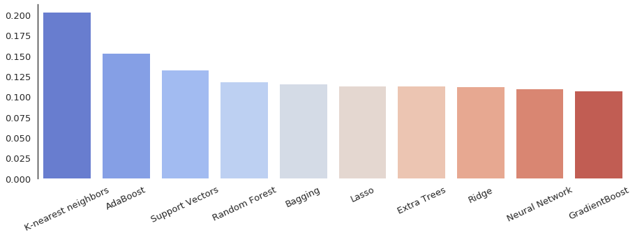

```python
X=[]; Y=[]
for model in overallScores:
    X.append(model)
    Y.append(overallScores[model])

points = [(model, overallScores[model]) for model in overallScores]
points.sort(key = lambda x: x[1], reverse=True)
X = [point[0] for point in points]
Y = [point[1] for point in points]

# graph from https://seaborn.pydata.org/examples/color_palettes.html
sns.set(style="white", context="talk")
f = plt.figure(figsize=(13, 5))
sns.barplot(X, Y, palette="coolwarm")
sns.despine(bottom=True)
plt.xticks(rotation=25)
plt.tight_layout(h_pad=3)
```

## 6.4 - Plotting observed and predicted *SalePrices*

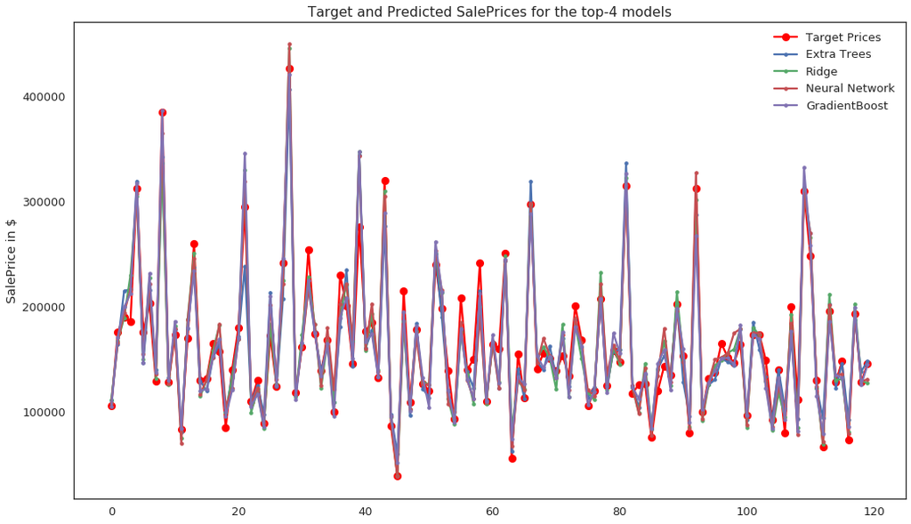

```python
plt.figure(figsize=(17, 10))
plt.plot(range(len(targetPrices)), targetPrices, 'ro-', label="Target Prices")
for model in [point[0] for point in points[-4:]]:
    plt.plot(range(len(targetPrices)), predictedPrices[model], '.-', label="{}".format(model))
plt.ylabel('SalePrice in \$')
plt.legend()
plt.title('Target and Predicted SalePrices for the top-4 models')
plt.show()
```

## 6.5 - Mix our top-2 models

What we see when computing the RMSE for the different models is that some of them do not always get much better results than the others. For example, Random Forest does not always get a better MSE than MLP. So we now want to merge the predictions from our two best models to see if we can find better predictions

- $k$ is the predicted price with the best model
- $n$ is the predicted price with the second best model
- $p$ is the new predicted price $$p = w \times r + (1-w)\times n$$

We need to find the weight $w$ such that the MSE for the new $p$ is miminal.

```python
bestModel = points[-1][0]
secondBestModel = points[-2][0]
print("Best model: {}\nSecond best model: {}".format(bestModel, secondBestModel))
```

```
Best model: GradientBoost
Second best model: Neural Network
```

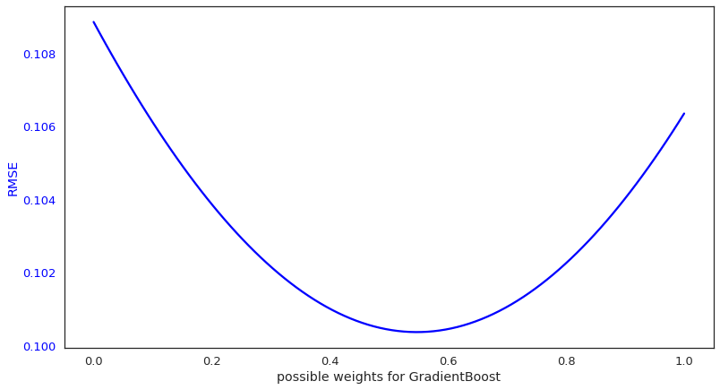

```
Best Weight for GradientBoost: 0.545
gives a RMSE of: 0.1004
```

```python
possible_weights = np.linspace(0, 1, 100)
mse=[]; r2=[]; minMSE=1
for weight in possible_weights:
    newPredictions = [weight*predictedPrices[bestModel][i] + (1-weight)*predictedPrices[secondBestModel][i] for i in range(len(predictions['Random Forest']))]
    tmp_mse = scoreRMSE(newPredictions, targetPrices)
    mse.append(tmp_mse)
    if tmp_mse<minMSE:
        minMSE=tmp_mse
        bestWeight=weight

plt.figure(figsize=(13, 7))
plt.plot(possible_weights, mse, 'b-')
plt.xlabel('possible weights for {}'.format(bestModel))
plt.ylabel('RMSE', color='b')
plt.tick_params('y', colors='b')
plt.show()

print("Best Weight for {}: {}\ngives a RMSE of: {}".format(bestModel, round(bestWeight, 3), round(minMSE, 4)))
```

## 6.6 - Predictions on the initial test dataset

The result after these transformation was stored in `norm_test`.

### Final Models

```python
## Datasets
norm_train_prices = norm_train['SalePrice']
norm_train_data = norm_train.drop('SalePrice', axis=1)

## Lasso
regressor_1=Lasso(alpha=5e-5)
params_1 = {
    'alpha':[5e-5],
    'max_iter':range(500)
}
name_1="Lasso"
rgr = GridSearchCV(regressor_1, params_1)
t0=time()
rgr.fit(norm_train_data, norm_train_prices)
print("Training %s took %.3fs." % ("Lasso", (time() - t0)))
print("\nLasso Regressor's params:\n", rgr.best_estimator_)
predictions_Lasso = rgr.predict(norm_test)

## MLP
scaler_mlp = StandardScaler()
scaler_mlp.fit(norm_train_data)
MLP_train = scaler_mlp.transform(norm_train_data)
MLP_test = scaler_mlp.transform(norm_test)
# initialization of the neural network
mlp = MLPRegressor(solver='lbfgs', activation='logistic', alpha=1)
# train the neural network
t0=time()
mlp.fit(MLP_train, norm_train_prices)
print("\nTraining the MLP took %.3fs" % (time() - t0))
predictions_MLP = mlp.predict(MLP_test)
```

```
Training Lasso took 57.557s.

Lasso Regressor's params:
 Lasso(alpha=5e-05, copy_X=True, fit_intercept=True, max_iter=499,
   normalize=False, positive=False, precompute=False, random_state=None,
   selection='cyclic', tol=0.0001, warm_start=False)

Training the MLP took 3.988s
```

```python
newPredictions = getPrices(
    [0.7*predictions_Lasso[i] + 0.3*predictions_MLP[i] for i in range(len(predictions_Lasso))],
    salePriceLambda
)
```

```python
df_test = pd.read_csv('./challenge_data/test.csv') # we get it back just to recover the house Ids

my_submission = pd.DataFrame({'Id': df_test.Id, 'SalePrice': newPredictions})
my_submission.to_csv('submission-01.csv', index=False)
```

# 7 - More on the cleaning section

We first had a much simpler approach to *Data Preparation and Preprocessing*, which we present here, as it is much simpler and faster than the one we adopted in the notebook. However, the results we were getting with that old approach were not too bad compared to the ones we get now.

```python
df_train = pd.read_csv('./challenge_data/train.csv')
df_test = pd.read_csv('./challenge_data/test.csv')
```

## 7.1 - Converting strings to numerical values

One of the first things we want to do is **transform all strings into floats**. This will allow us to only deal with numerical values. But we need to have all numbers representing the same values between the training and test datasets. To do so, we are going to build a dictionary `dico_train` from the *training dataset* where for each column there will be a sub-dictionary associating a different number to every possible string value of that column.

For example:

```
dico_train = {
    'BsmtCond': {
        'Po': 0,
        'Gd': 1,
        'Ex': 2,
        'None': -1 },
    'SaleType': {
        'ConLD': 1,
        'ConLI': 2,
        'ConLw': 3,
        'Con': 4 }}
```

Then we will use *this same dictionary* to convert the strings into numbers in the *test dataset*.

For some columns ('quality' columns), the strings correspond to a rating, so we will build a specific dictionary for those strings, to keep the ordering of the rating:

| Condition | Grade |
| --- | --- |
| 10 | Very Excellent |
| 9 | Excellent |
| 8 | Very Good |
| 7 | Good |
| 6 | Above Average |
| 5 | Average |
| 4 | Below Average |
| 3 | Fair |
| 2 | Poor |
| 1 | Very Poor |

```python
qual_dico = {
    'Ex':9,
    'Gd':7,
    'TA':5,
    'Fa':3,
    'Po':2,
    'NA':-1
}
```

```python
# Replacing "quality" columns
cnt=0
for col in df_train.select_dtypes('object').columns:
    if ('Qu' in col or 'Cond' in col or 'QC' in col) and ('Condi' not in col):
        df_train[col]=df_train[col].map(qual_dico)
        df_test[col]=df_test[col].map(qual_dico)
        cnt+=1
print("{} cols were replaced.".format(cnt))
```

```
10 cols were replaced.
```

```python
# Replacing other strings
t0=time()
dico_train = {}
for col in df_train.select_dtypes('object').columns:
    tmp = {}; counter=0
    for item in df_train[col]:
        if (item not in tmp) and (type(item) is str):
            tmp[item]=counter
            counter+=1
    df_train[col]=df_train[col].map(tmp)
    dico_train[col]=tmp
print('[training data] converting strings into numerals took %.2fs' % (time() - t0))

t0=time()
for col in df_test.select_dtypes('object').columns:
    df_test[col]=df_test[col].map(dico_train[col])
print('[test data] converting strings into numerals took %.2fs' % (time() - t0))
```

```
[training data] converting strings into numerals took 0.00s
[test data] converting strings into numerals took 0.00s
```

## 7.2 - Replacing `nan` values

Next, we are going to replace all `nan` values with something more significant and that we can actually use in computations (`nan` does not go well with computations...). There are different strategies to take care of it:

- replace it with the column median
- replace it with the column mean
- replace it with a random number taken from the set of other values in the column
- replace it with 0 or -1, depending on the column (or a more significant value, depending on the column values)
- drop col/row, which we will not try here because we would lose too much information

Before choosing a replacement strategy for all of our columns, let us study a bit more in details our columns with `nan` values:

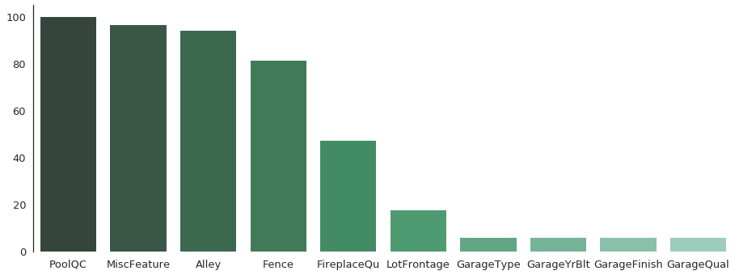

```python
nans = [(col, df_train[col].isnull().sum()/12.) for col in df_train.columns]
nans.sort(key = lambda x: x[1], reverse=True)
nbrPoints=10
X = [nans[i][0] for i in range(nbrPoints)]
Y = [nans[i][1] for i in range(nbrPoints)]

# graph from https://seaborn.pydata.org/examples/color_palettes.html
sns.set(style="white", context="talk")
f = plt.figure(figsize=(13, 5))
sns.barplot(X, Y, palette="BuGn_d")
sns.despine(bottom=True)
plt.tight_layout(h_pad=3)
```

What we see here is that for most columns (starting with `GarageType`), there are only a few `nan` values. Therefore replacing them with the column median or mean looks like it could be a good idea. We'll look into that later. But for the 6 first columns, we can see that we might lose information by replacing `nan` with the median or the mean. For example, more than 95% of the houses do not have a pool, but if we decide to replace the `nan` with the median, we will have a new dataset where all houses have a pool, which is too far from the reality.

```python
# replace <nan> with -1 is specific columns (with too many <nan> to use the median)
for col in ['PoolQC', 'MiscFeature', 'Alley', 'Fence', 'FireplaceQu', 'LotFrontage']:
    df_train[col]=df_train[col].map(lambda x: -1 if isnan(x) else x)
    df_test[col]=df_test[col].map(lambda x: -1 if isnan(x) else x)

# other colummns: replace <nan> with the column median
df_train = df_train.apply(lambda x: x.fillna(x.mean()),axis=0)
df_test = df_test.apply(lambda x: x.fillna(x.mean()),axis=0)
```

## 7.3 - Skewness

What we can observe next is that the data distributions are too asymetric, so we wish to make them more 'normal', in order to be able to use more models (which assume the datasets are close to normal distributions). To do so, we are going to apply the **Box-Cox transformation** to our columns.

**Note:** We do not apply it to three columns (`YearRemodAdd`, `YearBuilt`, `GarageYrBlt`), because the resulting values are too high for some of the computations we do later on. More specifically, they are too high to be put into `float32` variables, which we need with some of the `sktlean` functions.

```python
t0=time()
norm_train = df_train.copy()
norm_test = df_test.copy()
for col in df_train.columns:
    if col not in ['YearRemodAdd', 'YearBuilt', 'GarageYrBlt']:
        norm_train[col] = norm_train[col].map(lambda y: y+2)
        lmbda=stats.boxcox_normmax(norm_train[col], (-5, 5))
        if col=='SalePrice': salePriceLambda = lmbda
        norm_train[col] = stats.boxcox(norm_train[col], lmbda)
        try:
            norm_test[col] = norm_test[col].map(lambda y: y+2)
            lmbda_test=stats.boxcox_normmax(norm_test[col], (-5, 5))
            norm_test[col] = stats.boxcox(norm_test[col], lmbda)
        except:
            pass # SalePrice not in norm_test
print('[TIME] Applying Box-Cox to training and test data took: %.3fs' % (time() - t0))
```

```
[TIME] Applying Box-Cox to training and test data took: 1.168s
```

We can see how this transformation can affect some of our dataset by plotting the distribution before and after the transformation:

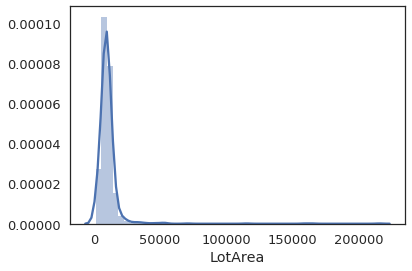

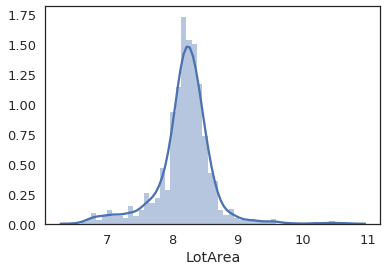

```python
col = 'LotArea' #df_train.columns[rd.randint(0, len(df_train.columns)-1)]
sns.distplot(df_train[col])
plt.show()
plt.figure()
sns.distplot(norm_train[col])
plt.show()
```

## 7.4 - Modeling and Evalution

Let us now try to work on the same datasets as we did in the earlier sections (when working with cross-validation, so the datasets are the same)

```python
regressor_1=Lasso(alpha=5e-5)
params_1 = {
    'alpha':[5e-5],
    'max_iter':range(500)
}
name_1="Lasso"
rgr = GridSearchCV(regressor_1, params_1)
t0=time()
rgr.fit(train_data, train_targets)
print("Training %s took %.3fs." % ("Lasso", (time() - t0)))
print("\nLasso Regressor's params:\n", rgr.best_estimator_)

predictions_Lasso = rgr.predict(test_data)
```

```
Training Lasso took 53.834s.

Lasso Regressor's params:
 Lasso(alpha=5e-05, copy_X=True, fit_intercept=True, max_iter=66,
   normalize=False, positive=False, precompute=False, random_state=None,
   selection='cyclic', tol=0.0001, warm_start=False)
```

```python
print("RMSE for Lasso with our cleaning strategy: %.4f" % 0.1126517063455773)
print("RMSE for Lasso with the old cleaning strategy: %.4f" % scoreRMSE(
    getPrices(predictions_Lasso, salePriceLambda),
    targetPrices
))
```

```
RMSE for Lasso with our cleaning strategy: 0.1127
RMSE for Lasso with the old cleaning strategy: 0.1179
```

# Conclusion

Throughout this notebook, we tried to predict house prices using a training set that was given to us. We did this through building **prediction models** that learned from the *training dataset* the right rules to predict the prices of the *test dataset*.

To go further, we could have (and maybe will) implemented more models, and gone into more details with the ones we tried (particularly the MLP, or the SVR). We also tried to implement an SGD regressor but did not have time to finish it. However, we could expect its results to be better than Lasso's. Moreover, we decided to remove only one outlier, but we could have gone further into the study (and removal) of these outliers.

# 8 - References

- General Documentation
  - [Ames Housing Dataset Documentation](https://ww2.amstat.org/publications/jse/v19n3/decock/datadocumentation.txt)
  - [Tuned Random Forest, Lasso and XGBoost Regressors](https://www.kaggle.com/hamzaben/tuned-random-forest-lasso-and-xgboost-regressors/notebook), by Hamza B. (on *Kaggle*)
- Box-Cox Transformation
  - [Box-Cox Transformation](http://www.statisticshowto.com/box-cox-transformation/), on *Statistics How To*
  - [Box-Cox Transformations: An Overview](http://avesbiodiv.mncn.csic.es/estadistica/curso2011/boxcox.pdf), by Pengfei Li
- Support Vector Machines
  - [A tutorial on support vector regression](https://web.cs.dal.ca/~tt/CSCI650806/projects/papers/SmolaSchoelkopf.pdf), by A. J. Smola and B. Schölkopf
  - [Machine Learning and Intelligent Systems course](http://www.eurecom.fr/en/course/MALIS-2017Fall), slides from Prof. B. Merialdo